# Olink ananlysis eliteATHENA and 2000HIV

Albert Groenendijk & Nadira Vadaq

2022-11-22

Updated July and December 2023 and January 2024 by Nadira. Major revisions, refactor and expansions by Albert, starting 9 February 2024, further additions October and December 2024.

```r
working_dir <- c("C:/Users/accou/Documents/PHD_2_projects/7_Code_for_github/AthenaOlink_DifferentialExpression_CrossSectional/")

library(FactoMineR)
library(dplyr)
library(magrittr)
library(lubridate)
library(table1)
library(ggbiplot)
library(ggplot2)
library(openxlsx)
```

## 0.1 Read Cleaned Data AthenaOlink

```r
master_df = readRDS(paste0(working_dir, "Inputs/AthenaOlink_EC_vs_VC_Cleaned.rds"))
```

**First, we inspect the distribution of covariates across groups, done in the cleaning script. Then we plot the impact of covariates on the data before and after correction.**

**Based on these exploratory analyses we decide what to correct for in our analyses.**

## 0.2 Define functions for PCA, and PC vs covariate regression

In the previous function `plot_PCA_regression()`, the FDR p values are reported for every regression model with FDR P < 0.05. The others are replaced by 0. This approach is not wrong but it diverges from what we agreed upon in the 2000HIV group with biostatisticians.

Importantly, the P value may not be right measure to evaluate confounding influence: if the effect is large but so is the variance, then the P value will be high. If the effect is small but so is the variance, then the P value will be low. This is one of the main reasons why it was decided to report the regression coefficients and not the P values. Calculating estimate change also has disadvantage when the estimates are small: from 0.02 to 0.04 is a 200% change.

Vicky (biostatistician) in email 30-6-2023:

*As potential confounders, we choose those that show a strong correlation. In principle, a correlation coefficient of 0.10 is thought to represent a weak or small association; a correlation coefficient of .30 is considered a moderate association, and a correlation of .50 or larger is thought to represent a strong or large correlation. Attached I have an example of the correlation between confounders and the PCs when using the bulk transcriptomic data from ECs. For example, we see that there is a strong correlation (0.55) between season cosine and PC1.*

*Build your regression model (linear model or rank-based) using the potential confounders that you choose from step 3. Extract the residuals from your regression model which are the corrected values of cytokines for the confounders of choice. Let’s say age, sex. In the rank-based regression R script, there is a block on how to extract the residuals; the output is a matrix with the sample ids and corrected values (residuals).*

In our data, AGE, BMI, CENTER and STORAGE_TIME should be evaluated for EC vs VC. And for Transient_VC vs persistent_VC there are only mild differences: VL, CENTER, ETHNICITY_WHITE.

```r
plot_PCA_regression <- function(pca,
                                meta_data,
                                meta_variables,
                                title = 'PC contribution',
                                plotname) {
  # Extract results
  pca_res <- pca$ind$coord
  # Select metadata to regress on
  meta_data_filtered <- meta_data %>% select(all_of(meta_variables))

  # Extract percentage of variance explained for xlabs
  pcnames <- paste0("PC", c(1:5), " (", round(pca$eig[c(1:5),"percentage of variance"],1), "%)")

  # Run linear regression model
  for(i in colnames(meta_data_filtered)){
    # Exclude metadata features with less than two unique variables
    if(length(unique(meta_data_filtered[ ,i])) <2 ){
      print(paste("exclude", i, sep = " "))
    }
  }
  # Initiate output dataframe
  pca_adj_r_sq <- matrix(data = NA, ncol = ncol(pca_res), nrow = ncol(meta_data_filtered)) %>%
    set_colnames(colnames(pca_res)) %>%
    set_rownames(colnames(meta_data_filtered))
  # Loop over combinations of metadata and PCs and fill dataframe
  for(i in 1:ncol(pca_res)){
    for(j in 1:ncol(meta_data_filtered)){
      pca_adj_r_sq[j,i] <- summary(lm(pca_res[,i] ~ meta_data_filtered[,j], na.action = na.exclude))$adj.r.squared
    }
  }

  colnames(pca_adj_r_sq) <- pcnames

  # Define color scheme
  paletteLength<-50
  my_palette <- colorRampPalette(c("blue", "white", "red"))(paletteLength)
  # Calculate most extreme rsq (either positive or negative)
  rsq_max <- max(abs(min(pca_adj_r_sq)), max(pca_adj_r_sq))
  breakList <- seq(-0.5, 0.5, by = (1/paletteLength))
  #breakList <- seq(-rsq_max, rsq_max, by = (2*rsq_max/paletteLength))
  # breakList <- c(seq(-rsq_max, 0, length.out = ceiling(paletteLength/2) + 1),
  #                seq(max(pca_adj_r_sq)/paletteLength, max(pca_adj_r_sq), length.out = floor(paletteLength/2)))
  # Plot heatmap

  hm <- pheatmap::pheatmap(as.matrix(pca_adj_r_sq),
                           cluster_rows = F,
                           cluster_cols = F,
                           show_rownames = T,
                           show_colnames = T,
                           scale = "none",
                           main = title,
                           display_numbers = T,
                           color= my_palette,
                           breaks = breakList)

  # to save pheatmap, use function.
  ### Source: https://stackoverflow.com/questions/43051525/how-to-draw-pheatmap-plot-to-screen-and-also-save-to-file
  save_pheatmap_pdf <- function(x, filename, width=4, height=5) {
   stopifnot(!missing(x))
   stopifnot(!missing(filename))
   pdf(paste0(working_dir,"Outputs/",filename), width=width, height=height)
   grid::grid.newpage()
   grid::grid.draw(x$gtable)
   dev.off()
  }

save_pheatmap_pdf(hm, plotname)
}
```

## 0.3 Perform PCA and plot PCs uncorrected against covariates

Missing metadata for CD4 (N = 2) and BMI (N = 31) were imputed with the median for the evaluation of covariates.

Missing metadata for categorical variables (smoking, ethnicity) were included as separate factor level called “UNKNOWN”.

Note that this is ONLY for evaluation of covariates. For the main analysis, individuals with missing information are excluded from the analysis.

```r
library(FactoMineR)
library(missMDA) # to impute PCA with the mean, in case of missing values, as advised by FactoMineR documentation
# select metadata with covariates
metadata <- master_df[,c("AGE", "SEX", "T1_BMI", "BMI_CAT", "ETHNICITY",
                         "ETHNICITY_WHITE", "ETHNICITY_BLACK",
                         "CENTER", "CENTER_EMC","CENTER_LUMC", "CENTER_MSZ",
                         "CENTER_OLVG", "CENTER_RAD", "CENTER_UMCU",
                         "SMOKING_EVER", "SMOKING_CURRENT",
                         "SEASON_COS","SEASON_SIN", "SEASON_CAT",
                         "T1_DATE", "STORAGE_TIME", "HIV_DUR",
                         "VL", "LOG10VL", "CD4", "CD4NADIR", "SQRTCD4", "SQRTCD4NADIR")]

# evaluate missingness in metadata:
colSums(is.na(metadata))
```

```
##             AGE             SEX          T1_BMI         BMI_CAT       ETHNICITY
##               0               0              31              31              23
## ETHNICITY_WHITE ETHNICITY_BLACK          CENTER      CENTER_EMC     CENTER_LUMC
##              23              23               0               0               0
##      CENTER_MSZ     CENTER_OLVG      CENTER_RAD     CENTER_UMCU    SMOKING_EVER
##               0               0               0               0              17
## SMOKING_CURRENT      SEASON_COS      SEASON_SIN      SEASON_CAT         T1_DATE
##              14               0               0               0               0
##    STORAGE_TIME         HIV_DUR              VL         LOG10VL             CD4
##               0               0               0               0               2
##        CD4NADIR         SQRTCD4    SQRTCD4NADIR
##               0               2               0
```

```r
# impute the two missing CD4 with the median CD4 count
metadata[which(is.na(metadata$CD4)),"CD4"] <- median(metadata$CD4,na.rm = T)
metadata[which(is.na(metadata$SQRTCD4)),"SQRTCD4"] <- median(metadata$SQRTCD4,na.rm = T)

# impute the 31 missing T1_BMI with the median BMI
metadata[which(is.na(metadata$T1_BMI)),"T1_BMI"] <- median(metadata$T1_BMI,na.rm = T)

# add a factor level "unknown" for BMI_CAT, ETHNICITY, ETHNICITY_WHITE, ETHNICITY_BLACK, SMOKING_EVER and SMOKING_CURRENT
for (var in c("BMI_CAT", "ETHNICITY", "ETHNICITY_WHITE", "ETHNICITY_BLACK", "SMOKING_EVER", "SMOKING_CURRENT")) {
  metadata[,var] <- factor(metadata[,var], levels = c(levels(metadata[,var]),"UNKNOWN"))
  metadata[which(is.na(metadata[,var])),var] <- "UNKNOWN"
}

# now there are no more missing data
colSums(is.na(metadata))
```

```
##             AGE             SEX          T1_BMI         BMI_CAT       ETHNICITY
##               0               0               0               0               0
## ETHNICITY_WHITE ETHNICITY_BLACK          CENTER      CENTER_EMC     CENTER_LUMC
##               0               0               0               0               0
##      CENTER_MSZ     CENTER_OLVG      CENTER_RAD     CENTER_UMCU    SMOKING_EVER
##               0               0               0               0               0
## SMOKING_CURRENT      SEASON_COS      SEASON_SIN      SEASON_CAT         T1_DATE
##               0               0               0               0               0
##    STORAGE_TIME         HIV_DUR              VL         LOG10VL             CD4
##               0               0               0               0               0
##        CD4NADIR         SQRTCD4    SQRTCD4NADIR
##               0               0               0
```

```r
# select npx protein expression data
npx <- master_df[,grep("Cardiometabolic|Inflammation|Neurology|Oncology", colnames(master_df))]

# check there are no duplicated columns (sum of all True/False treats True as 1 and False as 0)
sum(duplicated(colnames(metadata),colnames(npx)))
```

```
## [1] 0
```

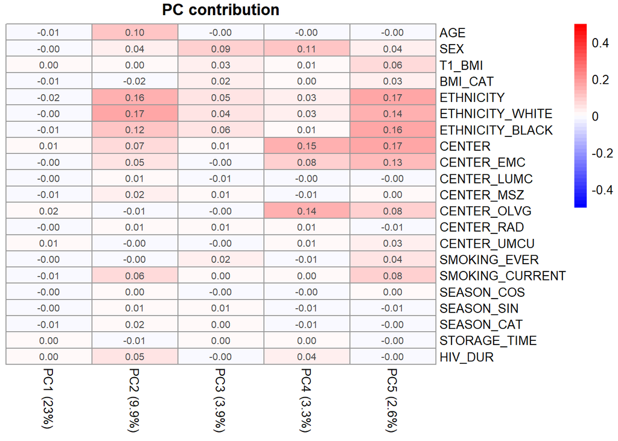

```r
# impute unknown npx values with missMDA::imputePCA(), as advised in the FactoMineR documentation
res.comp <- imputePCA(npx,ncp=5)
PCA_before_correction <- PCA(res.comp, scale.unit = T, graph = F)

# plot the PCA before correction
plot_PCA_regression(PCA_before_correction,
                    meta_data = metadata,
                    meta_variables = c("AGE","SEX", "T1_BMI", "BMI_CAT", "ETHNICITY",
                                       "ETHNICITY_WHITE", "ETHNICITY_BLACK",
                                       "CENTER", "CENTER_EMC","CENTER_LUMC", "CENTER_MSZ",
                                       "CENTER_OLVG", "CENTER_RAD", "CENTER_UMCU",
                                       "SMOKING_EVER", "SMOKING_CURRENT",
                                       "SEASON_COS","SEASON_SIN", "SEASON_CAT",
                                       "STORAGE_TIME", "HIV_DUR"
                                       #,"VL","LOG10VL","CD4", "CD4NADIR", "SQRTCD4", "SQRTCD4NADIR"
                                       ),
                    plotname = "Supplements_PCA_regression_uncorrected.pdf"
                    )
```

### 0.3.1 Interpretation covariates and confounding

The following variables could have an influence and should be evaluated: * ETHNICITY, especially ETHNICITY_WHITE * AGE * SEX * CENTER, specifically CENTER_EMC and CENTER_OLVG

The effect of other variables is minimal.

Note: Since ETHNICITY is missing in N=23 individuals, we will not be able to correct for ETHNICITY in the whole group of the main analysis.

In our data, AGE, BMI, CENTER and STORAGE_TIME should be evaluated for EC vs VC. * For BMI, a sensitivity stratification with boxplots will suffice, as Nadira already did before * STORAGE_TIME is worth correcting for, either as main model or as sensitivity * AGE is worth correcting for. * ETHNICITY and CENTER should be explored in terms of confounding

And for Transient_VC vs persistent_VC there are only mild differences at baseline: VL, CENTER, ETHNICITY_WHITE. * ETHNICITY_WHITE and CENTER_EMC and CENTER_OLVG should be explored in terms of confounding * beware that CENTER_EMC and CENTER_OLVG are also directly related to the outcome: much more Transient_VC in these centers. Therefore, stratification across groups may be required. * a sensitivity with VL is a good idea, although the effect is expected to be minimal

### 0.3.2 Limma regression and extract the residuals

```r
library(limma)

head(metadata) # contains all metadata
```

```
##        AGE    SEX   T1_BMI BMI_CAT ETHNICITY ETHNICITY_WHITE ETHNICITY_BLACK
## 1 42.87474   MALE 22.78331   21-25     White               1               0
## 2 64.14511 FEMALE 24.16383   21-25     White               1               0
## 3 33.84257   MALE 26.21882     >25   UNKNOWN         UNKNOWN         UNKNOWN
## 4 48.76660   MALE 24.93783 UNKNOWN     White               1               0
## 5 45.08693   MALE 22.49135   21-25     Black               0               1
## 6 47.77276   MALE 22.75831   21-25     White               1               0
##   CENTER CENTER_EMC CENTER_LUMC CENTER_MSZ CENTER_OLVG CENTER_RAD CENTER_UMCU
## 1    RAD          0           0          0           0          1           0
## 2   OLVG          0           0          0           1          0           0
## 3    MSZ          0           0          1           0          0           0
## 4   OLVG          0           0          0           1          0           0
## 5   OLVG          0           0          0           1          0           0
## 6   UMCU          0           0          0           0          0           1
##   SMOKING_EVER SMOKING_CURRENT SEASON_COS SEASON_SIN SEASON_CAT    T1_DATE
## 1            1               1  0.9834048  0.1814251     Winter 2015-01-12
## 2            1               0 -0.2358748 -0.9717834     Summer 2013-09-18
## 3            1               1 -0.5397796 -0.8418064     Summer 2006-08-30
## 4            0               0 -0.3896135  0.9209785     Spring 2011-04-26
## 5            1               1  0.9045483  0.4263711     Winter 2015-01-27
## 6      UNKNOWN         UNKNOWN -0.5637020 -0.8259782     Summer 2017-08-28
##   STORAGE_TIME HIV_DUR   VL  LOG10VL  CD4 CD4NADIR  SQRTCD4 SQRTCD4NADIR
## 1         2546    7.31 3000 3.477121  870      820 29.49576     28.63564
## 2         3027    7.10  857 2.932981  950     1080 30.82207     32.86335
## 3         5603    0.04    0 1.698970 1170     1170 34.20526     34.20526
## 4         3903   17.83    0 1.698970  910      640 30.16621     25.29822
## 5         2531    5.29 7850 3.894870 1060      920 32.55764     30.33150
## 6         1587    9.78 4420 3.645422  410      347 20.24846     18.62794
```

```r
head(npx) # contains all protein expression data
```

```
##   GP2_Cardiometabolic WASF1_Cardiometabolic HK2_Cardiometabolic
## 1             -0.8180                2.0341             -0.7271
## 2             -0.6583               -0.1658             -0.6835
## 3              1.0301               -1.3213             -1.1626
## 4             -0.1845               -1.4444              0.3448
## 5              0.5385               -0.3984             -0.7213
## 6             -0.4883                1.1483             -1.0743
##   VSTM2L_Cardiometabolic TIA1_Cardiometabolic MPHOSPH8_Cardiometabolic
## 1                -1.1273               0.7036                   0.2372
## 2                 0.3835              -0.8875                  -0.8112
## 3                -0.6029              -1.6819                  -0.8491
## 4                -0.3049              -2.7599                  -2.1583
## 5                -0.4466              -0.4420                  -0.7874
## 6                -0.2849               2.0960                   1.2937
##   HNRNPK_Cardiometabolic CEBPB_Cardiometabolic VIM_Cardiometabolic
```

[output cut: 4710 more lines]

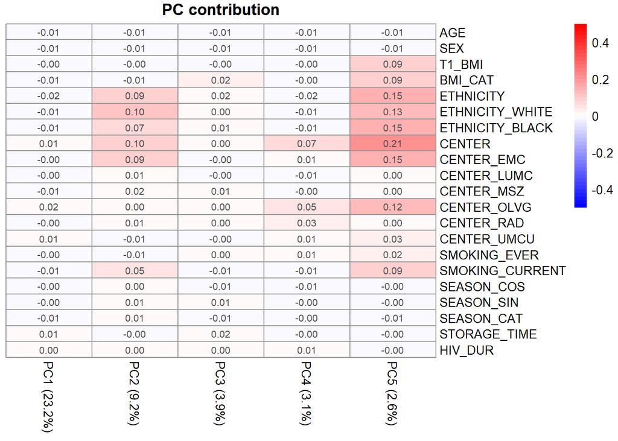

```r
# create function to provide PCAregression after inserting the design matrix, and plot title.
f <- function(design_cov,ti) {
# if there are NA in any of the covariates, the error will be: row dimension of design doesn't match column dimension of data object
# in this case, people with NA values should be removed, which we have done above for clinical columns using na.omit

# Generate the protein expression matrix
eset <- as.matrix(t(npx))  # Transpose data
dim(eset)
# [1] 2420  183

#Fitting model
fit1_cov <- lmFit(eset, design_cov) # limma assumes log-transformed data, which the NPX values already are

# Limma residuals matrix
ResidualsMatrix <- residuals(fit1_cov, eset)
# View(ResidualsMatrix)

dim(ResidualsMatrix)
#[1] 2420  183

# turn residuals into a data.frame in same order as metadata
Residualsdf <- data.frame(t(ResidualsMatrix))
sum(rownames(metadata) == rownames(Residualsdf)) # this should be same as the total no. of individuals

# Rerun PCA after correction
res.comp <- imputePCA(Residualsdf,ncp=5)
PCA_after_correction <-  PCA(res.comp,
                            graph = FALSE, scale.unit = TRUE)

# plot the PCs against selected covariates
plot_PCA_regression(PCA_after_correction,
                    meta_data = metadata,
                    meta_variables = c("AGE","SEX", "T1_BMI", "BMI_CAT", "ETHNICITY",
                                       "ETHNICITY_WHITE", "ETHNICITY_BLACK",
                                       "CENTER", "CENTER_EMC","CENTER_LUMC", "CENTER_MSZ",
                                       "CENTER_OLVG", "CENTER_RAD", "CENTER_UMCU",
                                       "SMOKING_EVER", "SMOKING_CURRENT",
                                       "SEASON_COS","SEASON_SIN", "SEASON_CAT",
                                       "STORAGE_TIME", "HIV_DUR"
                                       #,"VL","LOG10VL","CD4", "CD4NADIR", "SQRTCD4", "SQRTCD4NADIR"
                                       ),
                    plotname = ti)
}



# See how corrections influence the data
design_AGE_SEX <- model.matrix(~AGE + SEX, data = master_df)
design_AGE_SEX_CENTEREMC <- model.matrix(~AGE + SEX + CENTER_EMC, data = master_df)
design_AGE_SEX_CENTEROLVG <- model.matrix(~AGE + SEX + CENTER_OLVG, data = master_df)
design_AGE_SEX_CENTER <- model.matrix(~AGE + SEX + CENTER, data = master_df)
design_AGE_SEX_CENTEREMC_STORAGETIME <- model.matrix(~AGE + SEX + CENTER_EMC + STORAGE_TIME, data = master_df)
design_AGE_SEX_ETHNICITYWHITE <- model.matrix(~AGE + SEX + ETHNICITY_WHITE, data = metadata) ## ethnicity requires metadata which has category "unknown"
design_AGE_SEX_CENTEREMC_ETHNICITYWHITE <- model.matrix(~AGE + SEX + CENTER_EMC + ETHNICITY_WHITE, data = metadata) ## ethnicity requires metadata which has category "unknown"
design_AGE_SEX_CENTEREMC_ETHNICITYWHITE_STORAGETIME <- model.matrix(~AGE + SEX + CENTER_EMC + ETHNICITY_WHITE + STORAGE_TIME, data = metadata) ## ethnicity requires metadata which has category "unknown"

# Running the functions
f(design_AGE_SEX,"Supplements_PCA_regression_AGE_SEX.pdf")
```

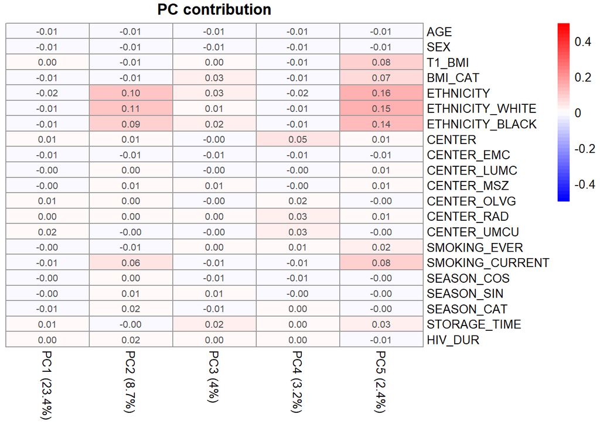

```r
f(design_AGE_SEX_CENTEREMC,"Supplements_PCA_regression_AGE_SEX_CENTEREMC.pdf" )
```

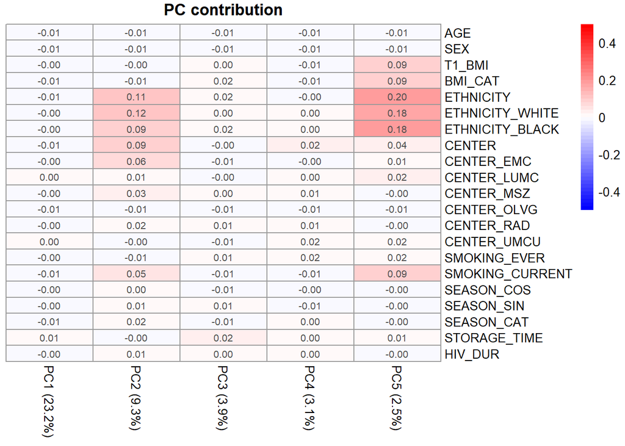

```r
f(design_AGE_SEX_CENTEROLVG,"Supplements_PCA_regression_AGE_SEX_CENTEROLVG.pdf" )
```

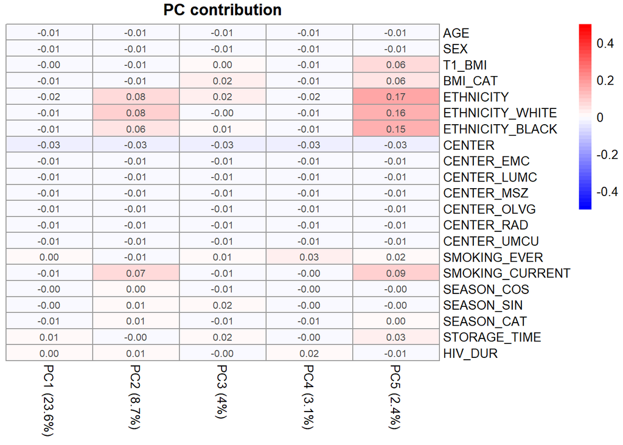

```r
f(design_AGE_SEX_CENTER, "Supplements_PCA_regression_AGE_SEX_CENTER.pdf")
```

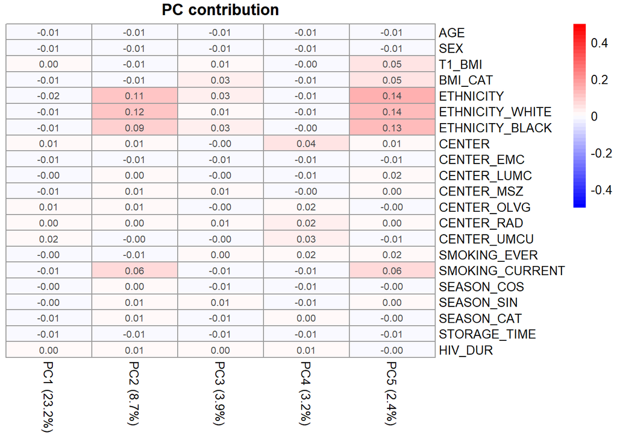

```r
f(design_AGE_SEX_CENTEREMC_STORAGETIME, "Supplements_PCA_regression_AGE_SEX_CENTER_STORAGETIME.pdf")
```

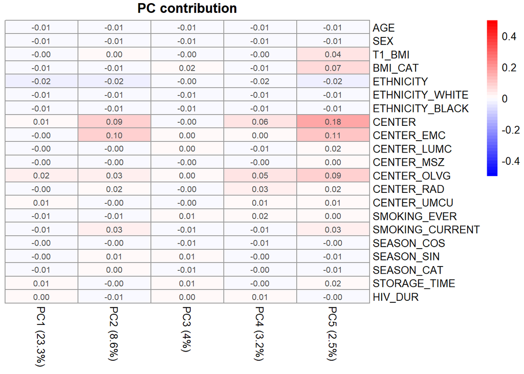

```r
f(design_AGE_SEX_ETHNICITYWHITE,"Supplements_PCA_regression_AGE_SEX_ETHNICITYWHITE.pdf")
```

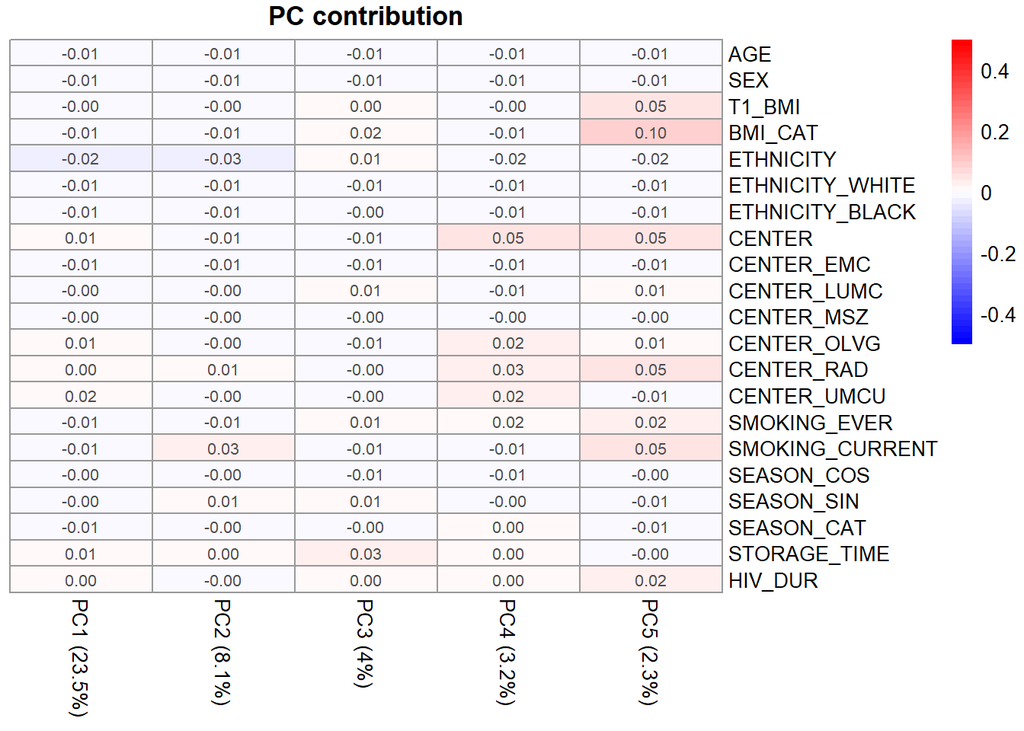

```r
f(design_AGE_SEX_CENTEREMC_ETHNICITYWHITE,"Supplements_PCA_regression_AGE_SEX_CENTEREMC_ETHNICITYWHITE.pdf" )
```

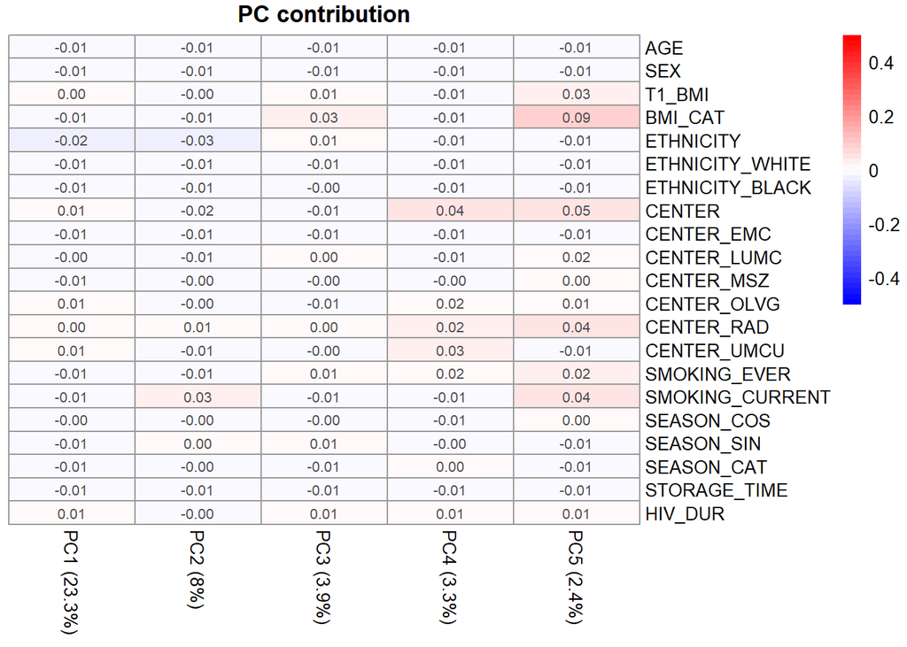

```r
f(design_AGE_SEX_CENTEREMC_ETHNICITYWHITE_STORAGETIME,"Supplements_PCA_regression_AGE_SEX_CENTEREMC_ETHNICITYWHITE.pdf" )
```

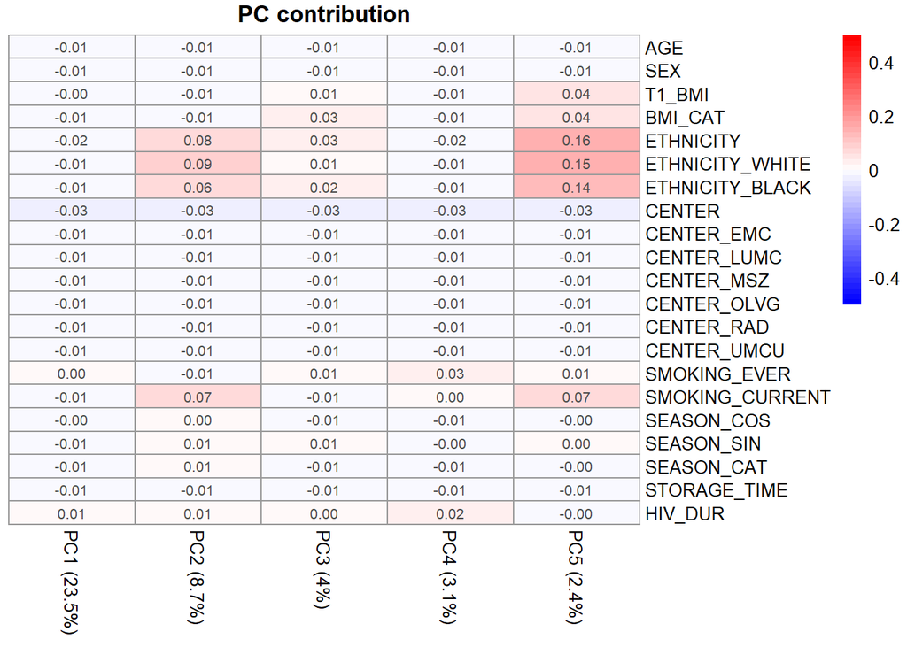

```r
# Nadira's model
design_AGE_SEX_CENTER_STORAGETIME <- model.matrix(~AGE + SEX + CENTER + STORAGE_TIME, data = master_df)
f(design_AGE_SEX_CENTER_STORAGETIME, "Supplements_PCA_regression_AGE_SEX_CENTER_STORAGETIME.pdf")
```

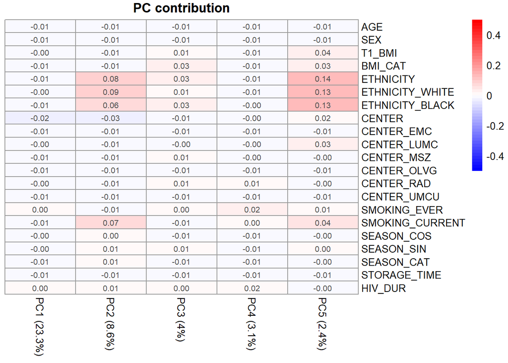

```r
# Nadira's model for prediction of loss
design_AGE_SEX_CENTEREMCOLVGUMCU_STORAGETIME <- model.matrix(~AGE + SEX + CENTER_EMC + CENTER_OLVG + CENTER_UMCU + STORAGE_TIME, data = master_df)
f(design_AGE_SEX_CENTEREMCOLVGUMCU_STORAGETIME, "Supplements_PCA_regression_AGE_SEX_CENTEREMCOLVGUMCU_STORAGETIME.pdf")
```

### 0.3.3 Explore if CENTER_EMC effect might be explained by EC vs VC or VCtransient vs VCpersistent

Do CENTER effects (especially CENTER_EMC) remain if we subset the data to VCpersistent (largest subgroup) or VCtransient?

```r
# the VCpersistent and VCtransient info was added to master_df during Cleaning script
master_df <- readRDS(paste0(working_dir, "Inputs/AthenaOlink_EC_vs_VC_Cleaned.rds"))

# identify rownumbers of VCpersistent and VCtransient
rnum_vc_persistent <- which(master_df$LOSS == "Persistent_VC")
rnum_vc_transient <- which(master_df$LOSS == "Transient_VC")

### run uncorrected PC regression for Persistent_VC
# subset the metadata and npx protein expression data
metadata_sub <- metadata[rnum_vc_persistent,]
npx_sub <- npx[rnum_vc_persistent,]

# verify rownumbers are the same
metadata_sub$T1_DATE == master_df[which(master_df$LOSS == "Persistent_VC"),"T1_DATE"]
```

```
##  [1] TRUE TRUE TRUE TRUE TRUE TRUE TRUE TRUE TRUE TRUE TRUE TRUE TRUE TRUE TRUE
## [16] TRUE TRUE TRUE TRUE TRUE TRUE TRUE TRUE TRUE TRUE TRUE TRUE TRUE TRUE TRUE
## [31] TRUE TRUE TRUE TRUE TRUE TRUE TRUE TRUE TRUE TRUE TRUE TRUE TRUE TRUE TRUE
## [46] TRUE TRUE TRUE TRUE TRUE TRUE TRUE TRUE TRUE TRUE TRUE TRUE TRUE TRUE TRUE
## [61] TRUE TRUE TRUE TRUE TRUE TRUE TRUE TRUE TRUE TRUE TRUE TRUE TRUE TRUE TRUE
## [76] TRUE TRUE TRUE TRUE TRUE TRUE TRUE TRUE TRUE TRUE TRUE TRUE TRUE TRUE TRUE
```

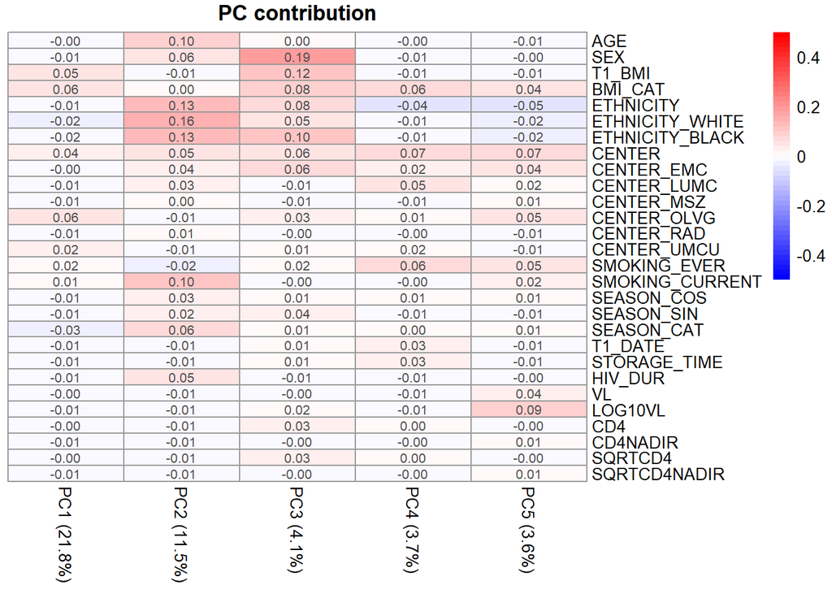

```r
# impute unknown npx values with missMDA::imputePCA(), as advised in the FactoMineR documentation
res.comp <- imputePCA(npx_sub,ncp=5)
PCA_before_correction <- PCA(res.comp, scale.unit = T, graph = F)

# plot the PCA before correction
plot_PCA_regression(PCA_before_correction,
                    meta_data = metadata_sub,
                    meta_variables = c("AGE","SEX", "T1_BMI", "BMI_CAT", "ETHNICITY",
                                       "ETHNICITY_WHITE", "ETHNICITY_BLACK",
                                       "CENTER", "CENTER_EMC","CENTER_LUMC", "CENTER_MSZ",
                                       "CENTER_OLVG", "CENTER_RAD", "CENTER_UMCU",
                                       "SMOKING_EVER", "SMOKING_CURRENT",
                                       "SEASON_COS","SEASON_SIN", "SEASON_CAT",
                                       "T1_DATE", "STORAGE_TIME", "HIV_DUR",
                                       "VL","LOG10VL","CD4", "CD4NADIR", "SQRTCD4", "SQRTCD4NADIR"),
                    plotname = "Supplements_PCA_regression_uncorrected_ONLY_VCpersistent.pdf"
                    )
```

```r
### run uncorrected PC regression for Transient_VC
# subset the metadata and npx protein expression data
metadata_sub <- metadata[rnum_vc_transient,]
npx_sub <- npx[rnum_vc_transient,]

# verify rownumbers are the same
metadata_sub$T1_DATE == master_df[which(master_df$LOSS == "Transient_VC"),"T1_DATE"]
```

```
##  [1] TRUE TRUE TRUE TRUE TRUE TRUE TRUE TRUE TRUE TRUE TRUE TRUE TRUE TRUE TRUE
## [16] TRUE TRUE TRUE TRUE TRUE TRUE TRUE TRUE TRUE TRUE TRUE TRUE TRUE TRUE TRUE
## [31] TRUE TRUE TRUE TRUE TRUE TRUE TRUE TRUE TRUE TRUE TRUE TRUE TRUE TRUE TRUE
## [46] TRUE TRUE TRUE TRUE TRUE TRUE TRUE TRUE TRUE TRUE
```

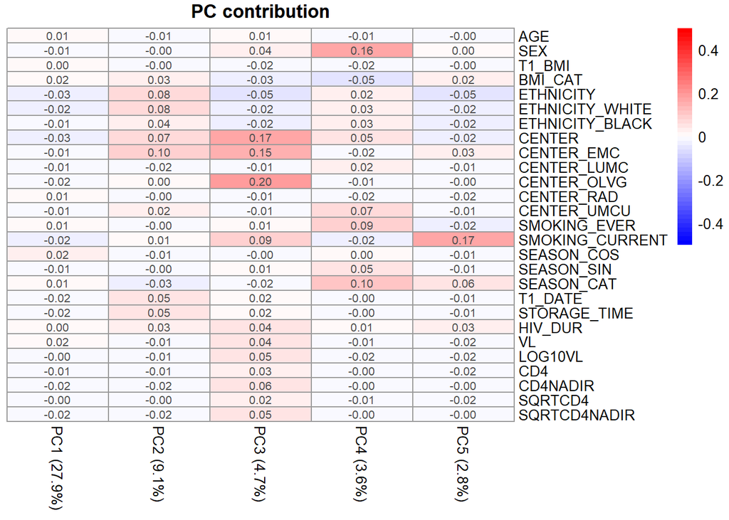

```r
# impute unknown npx values with missMDA::imputePCA(), as advised in the FactoMineR documentation
res.comp <- imputePCA(npx_sub,ncp=5)
PCA_before_correction <- PCA(res.comp, scale.unit = T, graph = F)

# plot the PCA before correction
plot_PCA_regression(PCA_before_correction,
                    meta_data = metadata_sub,
                    meta_variables = c("AGE","SEX", "T1_BMI", "BMI_CAT", "ETHNICITY",
                                       "ETHNICITY_WHITE", "ETHNICITY_BLACK",
                                       "CENTER", "CENTER_EMC","CENTER_LUMC", # "CENTER_MSZ", # CENTER MSZ does not have transient VC
                                       "CENTER_OLVG", "CENTER_RAD", "CENTER_UMCU",
                                       "SMOKING_EVER", "SMOKING_CURRENT",
                                       "SEASON_COS","SEASON_SIN", "SEASON_CAT",
                                       "T1_DATE", "STORAGE_TIME", "HIV_DUR",
                                       "VL","LOG10VL","CD4", "CD4NADIR", "SQRTCD4", "SQRTCD4NADIR"),
                    plotname = "Supplements_PCA_regression_uncorrected_ONLY_VCtransient.pdf"
                    )
```

## 0.4 Run linear regression EC vs VC in eliteATHENA (discovery)

We corrected previously for AGE, SEX, CENTER (all) and STORAGE_TIME. CENTER (all) creates 5 dummy variables. Since the total sample size is 183, there is little risk of overfitting.

Correction for AGE, SEX, CENTER and STORAGE_TIME can be defended. Correction for CENTER_EMC seems already sufficient in the PC regression.

Because ETHNICITY was similar between EC and VC, we do only a sensitivity analysis with ETHNICITY_WHITE.

```r
# select npx protein expression data
npx <- master_df[,grep("Cardiometabolic|Inflammation|Neurology|Oncology", colnames(master_df))]

# Generate the protein expression matrix
eset <- as.matrix(t(npx))  # Transpose data
dim(eset)
```

```
## [1] 2420  183
```

```r
# [1] 2420  183

# Design matrix
design_cov <- model.matrix(~ NONVIREMIC + AGE + SEX + CENTER + STORAGE_TIME, data = master_df)

# Fitting model
fit1_cov <- lmFit(eset, design_cov) # limma assumes log-transformed data. Note: the NPX values already are log-transformed.
cont.matrix_cov <- makeContrasts(NONVIREMICVC,
                                 levels = design_cov)
fit2_cov <- contrasts.fit(fit1_cov,cont.matrix_cov)
fit2_cov <- eBayes(fit2_cov)

# You can verify that the covariates for EC, VC and Early_ART are the same before and after adding contrasts.
#head(fit1_cov$coefficients)
#head(fit2_cov$coefficients)

# Note that sometimes a warning is generated because `(Intercept)` was renamed to `Intercept`
### That is also why another warning is generated: "Warning: row names of contrasts don't match col names of coefficients"
#colnames(fit1_cov$coefficients)
#rownames(cont.matrix_cov)

# Display "N" number of differentially expressed proteins
DEP_cov <- topTable(fit2_cov, coef = "NONVIREMICVC", adjust = "BH", number = 2421) %>%
  mutate(Outcome = rownames(.))
DEP_cov_sig <- DEP_cov[DEP_cov$adj.P.Val<0.05,]

#Display number of proteins significantly expressed in two groups
results_cov <- decideTests(fit2_cov)

summary(results_cov)
```

```
##        NONVIREMICVC
## Down              1
## NotSig         2416
## Up                3
```

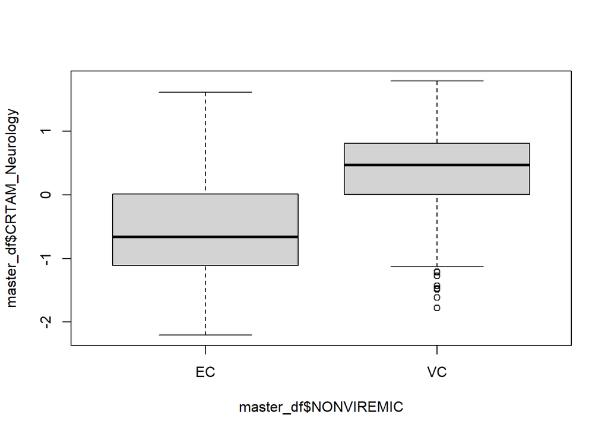

```r
# double check group assignment and interpretation
boxplot(master_df$CRTAM_Neurology~master_df$NONVIREMIC)
```

```r
help(sort)
```

```
## starting httpd help server ... done
```

```r
#Save the file
mod2_save <- DEP_cov %>%
  mutate(Try= gsub("_II","2",Outcome)) %>%
  tidyr::extract(Try, into = c("Outcome", "Panel"), "(.*)_([^_]+)$")  %>%
  mutate(Panel = gsub("2","_II",Panel))
mod2_save <- mod2_save[,c(7,1:6,8)]
openxlsx::write.xlsx(mod2_save,paste0(working_dir, "Outputs/Supplements_LIMMA_Olink_SHM_Comparison1_147ARTnaiveVC_vs_36EC_2420Prots_AGE_SEX_CENTER.xlsx"))
```

### 0.4.1 Sensitivity analyses correcting for CENTER_EMC, CENTER_OLVG and/or CENTER_MSZ only

```r
##########################
### Sensitivity analyses I
limma_ECVC_sensitivity <- function(design_cov) {
# This function uses the eset as defined above
# Fitting model
fit1_cov <- lmFit(eset, design_cov) # limma assumes log-transformed data. Note: the NPX values already are log-transformed.
cont.matrix_cov <- makeContrasts(NONVIREMICVC,
                                 levels = design_cov)
fit2_cov <- contrasts.fit(fit1_cov,cont.matrix_cov)
fit2_cov <- eBayes(fit2_cov)
# Display "N" number of differentially expressed proteins
DEP_cov <- topTable(fit2_cov, coef = "NONVIREMICVC", adjust = "BH", number = 2421) %>%
  mutate(Outcome = rownames(.))
DEP_cov_sig <- DEP_cov[DEP_cov$adj.P.Val<0.05,]
print(rownames(DEP_cov_sig))
results_cov <- decideTests(fit2_cov)
return(summary(results_cov))
}

suppressWarnings(limma_ECVC_sensitivity(model.matrix(~ NONVIREMIC + AGE + SEX + CENTER_EMC + STORAGE_TIME, data = master_df)))
```

```
## [1] "CRTAM_Neurology"       "LY9_Inflammation"      "CD6_Inflammation"
## [4] "CD27_Oncology"         "ICAM3_Cardiometabolic" "CXCL13_Neurology"
## [7] "TNFRSF8_Neurology"
```

```
##        NONVIREMICVC
## Down              0
## NotSig         2413
## Up                7
```

```r
suppressWarnings(limma_ECVC_sensitivity(model.matrix(~ NONVIREMIC + AGE + SEX + CENTER_OLVG + STORAGE_TIME, data = master_df)))
```

```
## [1] "CRTAM_Neurology"       "LY9_Inflammation"      "CD6_Inflammation"
## [4] "CD27_Oncology"         "ICAM3_Cardiometabolic"
```

```
##        NONVIREMICVC
## Down              0
## NotSig         2415
## Up                5
```

```r
suppressWarnings(limma_ECVC_sensitivity(model.matrix(~ NONVIREMIC + AGE + SEX + CENTER_EMC + CENTER_MSZ + STORAGE_TIME, data = master_df)))
```

```
## [1] "CRTAM_Neurology"  "LY9_Inflammation" "CD6_Inflammation"
```

```
##        NONVIREMICVC
## Down              0
## NotSig         2417
## Up                3
```

```r
suppressWarnings(limma_ECVC_sensitivity(model.matrix(~ NONVIREMIC + AGE + SEX + CENTER + STORAGE_TIME, data = master_df)))
```

```
## [1] "CRTAM_Neurology"  "LY9_Inflammation" "VAT1_Oncology"    "CD6_Inflammation"
```

```
##        NONVIREMICVC
## Down              1
## NotSig         2416
## Up                3
```

```r
suppressWarnings(limma_ECVC_sensitivity(model.matrix(~ NONVIREMIC + AGE + SEX + CENTER, data = master_df)))
```

```
##  [1] "CRTAM_Neurology"          "LY9_Inflammation"
##  [3] "TNFRSF8_Neurology"        "CD27_Oncology"
##  [5] "CD6_Inflammation"         "ICAM3_Cardiometabolic"
##  [7] "VAT1_Oncology"            "TNFRSF17_Inflammation_II"
##  [9] "CXCL13_Neurology"         "ARG1_Oncology"
## [11] "RBP7_Oncology_II"
```

```
##        NONVIREMICVC
## Down              3
## NotSig         2409
## Up                8
```

```r
suppressWarnings(limma_ECVC_sensitivity(model.matrix(~ NONVIREMIC + AGE + SEX + CENTER + STORAGE_TIME, data = master_df)))
```

```
## [1] "CRTAM_Neurology"  "LY9_Inflammation" "VAT1_Oncology"    "CD6_Inflammation"
```

```
##        NONVIREMICVC
## Down              1
## NotSig         2416
## Up                3
```

```r
# part 3 model
suppressWarnings(limma_ECVC_sensitivity(model.matrix(~ NONVIREMIC + AGE + SEX + CENTER_EMC + CENTER_OLVG + CENTER_UMCU + STORAGE_TIME, data = master_df)))
```

```
## [1] "CRTAM_Neurology"       "LY9_Inflammation"      "CD6_Inflammation"
## [4] "VAT1_Oncology"         "CD27_Oncology"         "ICAM3_Cardiometabolic"
```

```
##        NONVIREMICVC
## Down              1
## NotSig         2414
## Up                5
```

```r
# report how many are in each center by group
summary(master_df$CENTER)
```

```
##  EMC LUMC  MSZ OLVG  RAD UMCU
##   52    5   16   83   10   17
```

```r
for (var in c("CENTER_EMC", "CENTER_OLVG", "CENTER_UMCU","CENTER_MSZ", "CENTER_LUMC", "CENTER_RAD")) {
  print(var)
  print(summary(master_df[,var]))
}
```

```
## [1] "CENTER_EMC"
##   0   1
## 131  52
## [1] "CENTER_OLVG"
##   0   1
## 100  83
## [1] "CENTER_UMCU"
##   0   1
## 166  17
## [1] "CENTER_MSZ"
##   0   1
## 167  16
## [1] "CENTER_LUMC"
##   0   1
## 178   5
## [1] "CENTER_RAD"
##   0   1
## 173  10
```

```r
summary(master_df$NONVIREMIC)
```

```
##  EC  VC
##  36 147
```

Interpretation: the results are very consistent: CRTAM, LY9 and CD6 are always significantly upregulated.

STORAGE_TIME does alter the number of significant proteins and should be included.

### 0.4.2 Sensitivity analysis with ETHNICITY

PC regression shows that correction for ETHNICITY_WHITE is sufficient.

A sensitivity analysis with ETHNICITY_WHITE: 1. Everyone with ETHNICITY == NA, is regarded as ETHNICITY_WHITE == 0. 2. Exclude individuals with ETHNICITY == NA.

The results with the first way are exactly the same. With the second way, statistical power is less, and only 2 DEPs are detected, instead of 4. The raw P values are <0.01, though with consistent direction.

This validates the main findings.

```r
### 1. Everyone with ETHNICITY == NA, is regarded as ETHNICITY_WHITE == 0.
df_ethnicity1 <- master_df
df_ethnicity1$ETHNICITY_WHITE[which(is.na(df_ethnicity1$ETHNICITY_WHITE))] <- 0
summary(df_ethnicity1$ETHNICITY_WHITE)
```

```
##  0  1
## 90 93
```

```r
# We keep all participants so the protein expression matrix is the same
eset <- as.matrix(t(npx))  # Transpose data
design_cov <- model.matrix(~ NONVIREMIC + AGE + SEX + CENTER + STORAGE_TIME + ETHNICITY_WHITE, data = df_ethnicity1)
# Fitting model
fit1_cov <- lmFit(eset, design_cov) # limma assumes log-transformed data. Note: the NPX values already are log-transformed.
cont.matrix_cov <- makeContrasts(NONVIREMICVC,
                                 levels = design_cov)
fit2_cov <- contrasts.fit(fit1_cov,cont.matrix_cov)
fit2_cov <- eBayes(fit2_cov)
# Display "N" number of differentially expressed proteins
DEP_cov <- topTable(fit2_cov, coef = "NONVIREMICVC", adjust = "BH", number = 2421) %>%
  mutate(Outcome = rownames(.))
DEP_cov_sig <- DEP_cov[DEP_cov$adj.P.Val<0.05,]
print(rownames(DEP_cov_sig))
```

```
## [1] "CRTAM_Neurology"  "LY9_Inflammation" "VAT1_Oncology"    "CD6_Inflammation"
```

```r
results_cov <- decideTests(fit2_cov)
summary(results_cov)
```

```
##        NONVIREMICVC
## Down              1
## NotSig         2416
## Up                3
```

```r
### 2. Exclude individuals with ETHNICITY == NA
exclude_rnum <- which(is.na(master_df$ETHNICITY))
eset2 <- as.matrix(t(npx[-exclude_rnum,]))
dim(eset2)
```

```
## [1] 2420  160
```

```r
design_cov <- model.matrix(~ NONVIREMIC + AGE + SEX + CENTER + STORAGE_TIME + ETHNICITY_WHITE, data = master_df[-exclude_rnum,])
dim(design_cov)
```

```
## [1] 160  11
```

```r
# Fitting model
fit1_cov <- lmFit(eset2, design_cov) # limma assumes log-transformed data. Note: the NPX values already are log-transformed.
```

```
## Coefficients not estimable: CENTERLUMC CENTERMSZ
```

```r
cont.matrix_cov <- makeContrasts(NONVIREMICVC,
                                 levels = design_cov)
fit2_cov <- contrasts.fit(fit1_cov,cont.matrix_cov)
fit2_cov <- eBayes(fit2_cov)
# Display "N" number of differentially expressed proteins
DEP_cov <- topTable(fit2_cov, coef = "NONVIREMICVC", adjust = "BH", number = 2421) %>%
  mutate(Outcome = rownames(.))
DEP_cov_sig <- DEP_cov[DEP_cov$adj.P.Val<0.05,]
print(rownames(DEP_cov_sig))
```

```
## [1] "CRTAM_Neurology"  "LY9_Inflammation"
```

```r
results_cov <- decideTests(fit2_cov)
summary(results_cov)
```

```
##        NONVIREMICVC
## Down              0
## NotSig         2418
## Up                2
```

### 0.4.3 Sensitivity analysis: Run linear regression by log10(VL)

Since EC and VC are distinguished by their viral loads, we should expect to see very similar findings with a linear predictor log10(viral load).

To be consistent, I correct for the same confounders.

```r
dim(eset)
```

```
## [1] 2420  183
```

```r
design_cov <- model.matrix(~ LOG10VL + AGE + SEX + CENTER + STORAGE_TIME, data = master_df)
# Fitting model
fit1_cov <- lmFit(eset, design_cov) # limma assumes log-transformed data. Note: the NPX values already are log-transformed.

cont.matrix_cov <- makeContrasts(LOG10VL = -1,
                                 levels = design_cov)
fit2_cov <- contrasts.fit(fit1_cov,cont.matrix_cov)
fit2_cov <- eBayes(fit2_cov)
# Display "N" number of differentially expressed proteins
DEP_cov <- topTable(fit2_cov, coef = "LOG10VL", adjust = "BH", number = 2421) %>%
  mutate(Outcome = rownames(.))
DEP_cov_sig <- DEP_cov[DEP_cov$adj.P.Val<0.05,]
print(rownames(DEP_cov_sig))
```

```
##   [1] "CCL14_Cardiometabolic"       "ITM2A_Inflammation"
##   [3] "PAM_Cardiometabolic"         "DCBLD2_Oncology"
##   [5] "PGLYRP2_Inflammation_II"     "IGFBPL1_Cardiometabolic"
##   [7] "NOTCH3_Cardiometabolic"      "LTBP2_Cardiometabolic"
##   [9] "PKD1_Cardiometabolic_II"     "IGFBP4_Neurology"
##  [11] "OSMR_Cardiometabolic"        "TGFBI_Cardiometabolic"
##  [13] "EDA2R_Oncology"              "XG_Cardiometabolic"
##  [15] "CXCL16_Cardiometabolic"      "PLXNB2_Cardiometabolic"
##  [17] "ADAMTSL2_Cardiometabolic_II" "A1BG_Inflammation_II"
##  [19] "OGN_Neurology"               "ANGPTL3_Cardiometabolic"
##  [21] "NAGPA_Inflammation_II"       "FABP3_Cardiometabolic_II"
##  [23] "COL6A3_Cardiometabolic"      "ELN_Cardiometabolic_II"
##  [25] "F7_Cardiometabolic"          "IGFBP7_Cardiometabolic"
##  [27] "FSTL3_Inflammation"          "EGFL7_Oncology"
##  [29] "GSR_Inflammation_II"         "APOC1_Inflammation_II"
```

[output cut: 216 more lines]

```r
results_cov <- decideTests(fit2_cov)
summary(results_cov)
```

```
##        LOG10VL
## Down        25
## NotSig    1959
## Up         436
```

```r
mod2_save <- DEP_cov %>%
  mutate(Try= gsub("_II","2",Outcome)) %>%
  tidyr::extract(Try, into = c("Outcome", "Panel"), "(.*)_([^_]+)$")  %>%
  mutate(Panel = gsub("2","_II",Panel))
mod2_save <- mod2_save[,c(7,1:6,8)]
openxlsx::write.xlsx(mod2_save,paste0(working_dir, "Outputs/Supplements_LIMMA_Olink_LOG10VL_2420Prots_AGE_SEX_CENTER_STORAGETIME.xlsx"))


DEP_cov[grep("CRTAM_|LY9_|CD6_I|VAT1_",rownames(DEP_cov)),]
```

```
##                       logFC     AveExpr         t    P.Value  adj.P.Val
## LY9_Inflammation 1.22423427  0.18080710 3.0575091 0.00258045 0.02164453
## CRTAM_Neurology  1.33530084  0.16381202 2.2689917 0.02448359 0.09306165
## CD6_Inflammation 0.78261725  0.48607869 1.1439560 0.25419632 0.41648957
## VAT1_Oncology    0.07596088 -0.08195628 0.2694487 0.78790028 0.86472503
##                          B          Outcome
## LY9_Inflammation -1.833932 LY9_Inflammation
## CRTAM_Neurology  -3.783582  CRTAM_Neurology
## CD6_Inflammation -5.607502 CD6_Inflammation
## VAT1_Oncology    -6.203379    VAT1_Oncology
```

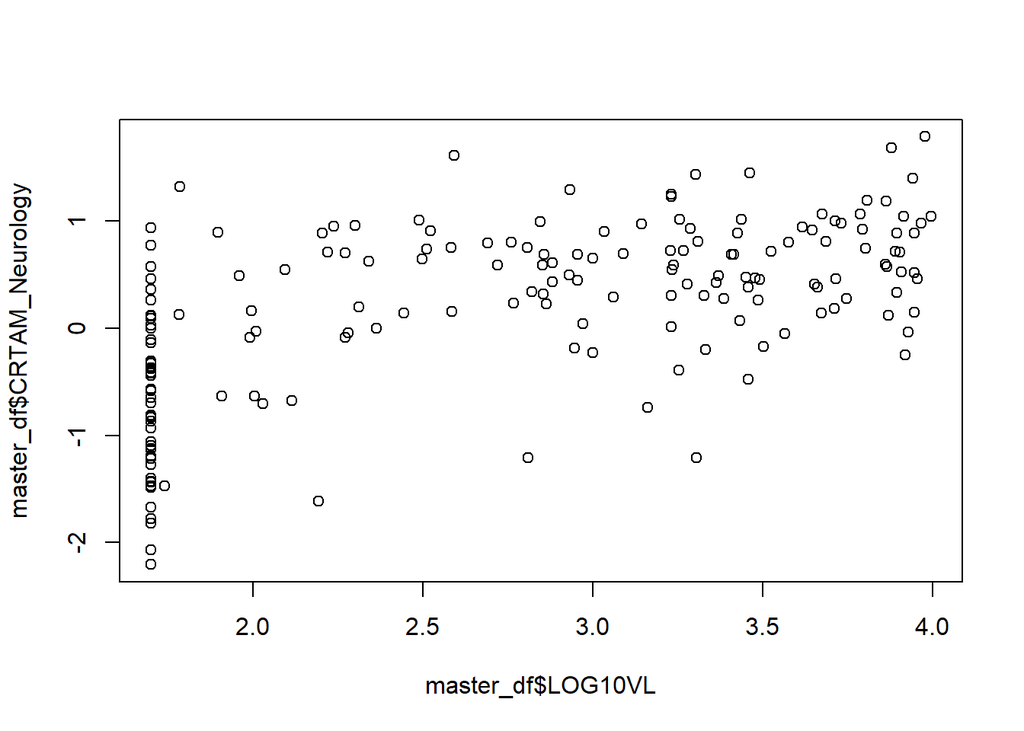

```r
plot(master_df$CRTAM_Neurology~master_df$LOG10VL)
```

```r
cor.test(master_df$CRTAM_Neurology,master_df$LOG10VL, method="spearman")[c("p.value","estimate")]
```

```
## $p.value
## [1] 1.269521e-18
##
## $estimate
##       rho
## 0.5910703
```

```r
cor.test(master_df$LY9_Inflammation,master_df$LOG10VL, method="spearman")[c("p.value","estimate")]
```

```
## $p.value
## [1] 3.875496e-15
##
## $estimate
##       rho
## 0.5382883
```

```r
cor.test(master_df$CD6_Inflammation,master_df$LOG10VL, method="spearman")[c("p.value","estimate")]
```

```
## $p.value
## [1] 2.746228e-16
##
## $estimate
##       rho
## 0.5567576
```

```r
cor.test(master_df$VAT1_Oncology,master_df$LOG10VL, method="spearman")[c("p.value","estimate")]
```

```
## $p.value
## [1] 7.354463e-05
##
## $estimate
##       rho
## -0.288776
```

### 0.4.4 Plot the EC vs VC FC against the LOG10VL FC

Define the colorgroup for P values as well.

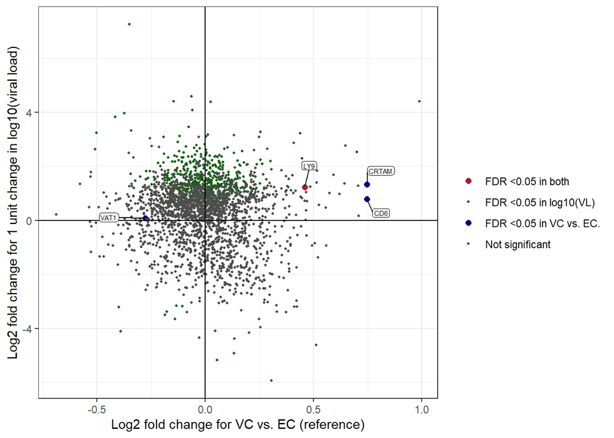

```r
ECVC <- openxlsx::read.xlsx(paste0(working_dir, "Outputs/Supplements_LIMMA_Olink_SHM_Comparison1_147ARTnaiveVC_vs_36EC_2420Prots_AGE_SEX_CENTER.xlsx"))
colnames(ECVC) <- paste0(colnames(ECVC),"_ECVC")
colnames(ECVC)[1] <- "Outcome"

VL <- openxlsx::read.xlsx(paste0(working_dir, "Outputs/Supplements_LIMMA_Olink_LOG10VL_2420Prots_AGE_SEX_CENTER_STORAGETIME.xlsx"))
colnames(VL) <- paste0(colnames(VL),"_LOG10VL")
colnames(VL)[1] <- "Outcome"

corrdata <- left_join(ECVC,VL,by="Outcome")
corrdata <- corrdata %>% mutate(COLORGROUP = case_when(adj.P.Val_ECVC < 0.05 & adj.P.Val_LOG10VL <0.05 ~ "FDR <0.05 in both",
                                                       adj.P.Val_ECVC > 0.05 & adj.P.Val_LOG10VL <0.05 ~ "FDR <0.05 in log10(VL)",
                                                       adj.P.Val_ECVC < 0.05 & adj.P.Val_LOG10VL >0.05 ~ "FDR <0.05 in VC vs. EC.",
                                                       adj.P.Val_ECVC > 0.05 & adj.P.Val_LOG10VL >0.05 ~ "Not significant"))
corrdata$COLORGROUP <- as.factor(corrdata$COLORGROUP)

corrdata <- corrdata %>% mutate(PROTEINLABEL = case_when(adj.P.Val_ECVC < 0.05 ~ Outcome,
                                                         adj.P.Val_ECVC > 0.05 ~ "" ))

PROTEINLABEL_OUTSIDE <- corrdata$PROTEINLABEL

# Create a scatter plot with a correlation line
options(ggrepel.max.overlaps = Inf)
ggplot(data = corrdata, aes(x = logFC_ECVC, y = logFC_LOG10VL, color = COLORGROUP)) +
  geom_point(aes(size = COLORGROUP)) +  # Add the dot plot
  #geom_smooth(method = "lm", se = FALSE, color = "black") +  # Add the correlation line
  geom_vline(xintercept = 0) + geom_hline(yintercept = 0) +
  scale_color_manual(values = c("#b2182b","darkgreen","darkblue","#4d4d4d"), name = "") +
  scale_size_manual(values = c(2, 0.75, 2, 0.75), name = "") +
  ylab("Log2 fold change for 1 unit change in log10(viral load)") +
  xlab("Log2 fold change for VC vs. EC (reference)") +
  theme_bw() + #geom_label(corrdata$PROTEINLABEL)
  ggrepel::geom_label_repel(
    label.size = .25, #Size of label border, in mm.
    box.padding = unit(0.45, "lines"),
    label.padding = 0.1, # Amount of padding around label, as unit or number.
    label.r = 0.15, #Radius of rounded corners,
    size = 2,
    aes(
      label = PROTEINLABEL_OUTSIDE,
      hjust = .5), color = "black")
```

### 0.4.5 Figure 1B - volcano discovery

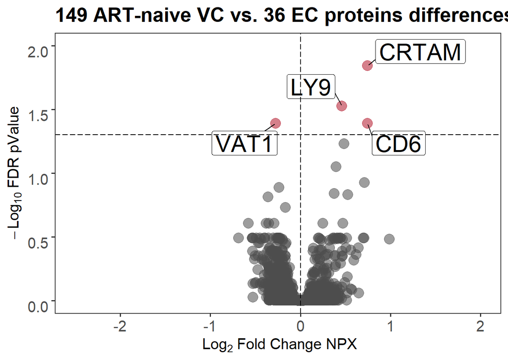

```r
#### GG PLOT VOLCANO #####
library(ggplot2)
library("ggrepel")
result2 <- openxlsx::read.xlsx(paste0(working_dir, "Outputs/Supplements_LIMMA_Olink_SHM_Comparison1_147ARTnaiveVC_vs_36EC_2420Prots_AGE_SEX_CENTER.xlsx"))
diff_df <- result2[,c(1,6,2)]
colnames(diff_df) <- c("Proteins", "pValue","Estimate")

# add a grouping column; default value is "not significant"
diff_df["group"] <- "NotSignificant"

# change the grouping for the entries with significance but not a large enough OR change
diff_df[which(diff_df['pValue'] < 0.05 ),"group"] <- "Significant"

diff_df$group <- as.factor(diff_df$group)
diff_df$Proteins <- as.character(diff_df$Proteins)
rownames(diff_df) <- diff_df$Proteins

diff_df_names <- diff_df
for (i in 1:nrow(diff_df_names))
  if(diff_df_names$pValue[i] < 0.05)#0.0000001; 5e-20
  {diff_df_names$Proteins[i] <- diff_df_names$Proteins[i]} else
  {diff_df_names$Proteins[i] <- ""}

options(ggrepel.max.overlaps = Inf)
ggplot(diff_df_names, aes(x=Estimate, y=-log10(pValue))) +

  #Add points:
  #   Colour based on factors set a few lines up
  #   'alpha' provides gradual shading of colour
  #   Set size of points
  geom_point(aes(color=group, alpha=0.8, size=0.8), show.legend = FALSE) +

  #Choose which colours to use; otherwise, ggplot2 choose automatically (order depends on how factors are ordered in diff_df$group)
  scale_color_manual(values=c("#4d4d4d","#b2182b")) +

  #Set the size of the plotting window
  theme_bw(base_size=14) +

  #Modify various aspects of the plot text and legend
  theme(legend.background=element_rect(),
        plot.title=element_text(angle=0, size=20, face="bold", vjust=1),

        panel.grid.major=element_blank(), #Remove gridlines
        panel.grid.minor=element_blank(), #Remove gridlines

        axis.text.x=element_text(angle=0, size=15, vjust=1),
        axis.text.y=element_text(angle=0, size=15, vjust=1),
        axis.title=element_text(size=15),

        #Legend
        # legend.position="top",        #Moves the legend to the top of the plot
        # legend.key=element_blank(),       #removes the border
        # legend.key.size=unit(0.5, "cm"),  #Sets overall area/size of the legend
        # legend.text=element_text(size=8), #Text size
        # title=element_text(size=8),       #Title text size
        # legend.title=element_blank()) +   #Remove the title
        legend.position = "none")+

  #Change the size of the icons/symbols in the legend
  guides(colour = guide_legend(override.aes=list(size=2.5))) +

  #Set x- and y-axes labels
  xlab(bquote(~Log[2]~"Fold Change NPX")) +
  ylab(bquote(~-Log[10]~"FDR pValue ")) +

  #Set title
  ggtitle("149 ART-naive VC vs. 36 EC proteins differences" ) +

  #Add the text labels for a Proteins
  geom_label_repel(
    label.size = .25, #Size of label border, in mm.
    box.padding = unit(0.45, "lines"),
    label.padding = 0.25, # Amount of padding around label, as unit or number.
    label.r = 0.15, #Radius of rounded corners,
    size = 8,
    aes(
      label = Proteins,
      hjust = .5))+

  #Add a vertical line for Estimate change cut-offs
  geom_vline(xintercept=c(0), linetype="longdash", colour="black", linewidth=0.4) +

  #Add a horizontal line for P-value cut-off
  geom_hline(yintercept=-log10(0.05), linetype="longdash", colour="black", linewidth=0.4)+
  xlim(c(-2.5,2)) + ylim(c(0,2))
```

```r
#Boxplot(merge_df$RBP7_Oncology_II~as.factor(merge_df$NONVIREMIC))

ggsave(paste0(working_dir, "Outputs/Figure1B_Volcano_label_0.05FDR_LIMMA_Olink_147VC_vs_36EC_2420Prots_AGE_SEX_CENTER_STORAGE.pdf"), plot = last_plot(), device = NULL, path = NULL,scale = 1, width = 15, height =12, units = 'in', dpi = 300)
```

### 0.4.6 Figures - boxplots CRTAM, LY9 CD6 and VAT1

#### 0.4.6.1 prepare data

```r
library("reshape2")

# Prepare the data
cocktails_df <- master_df %>%
  dplyr::select( "ID", "NONVIREMIC","SMOKING_CURRENT","T1_BMI","VL",
                 "CRTAM_Neurology","LY9_Inflammation","CD6_Inflammation","VAT1_Oncology") %>%
  mutate(BMI_cat2 = case_when(T1_BMI <18.5 ~ "BMI <18.5",
                             T1_BMI >=18.5 & T1_BMI <24.9 ~ "BMI 18.5-24.9",
                             T1_BMI >=25 ~ "BMI >=25"),
         SMOKING_CURRENT = ifelse(SMOKING_CURRENT==0,"Smoking (+)","Smoking (-)"))%>%
  dplyr::mutate(VL_cat = case_when( NONVIREMIC=="EC" ~ "EC",
                            NONVIREMIC=="VC" & VL < 400 ~ "50-400",
                            NONVIREMIC=="VC" & VL >= 400 & VL < 2000 ~ "400-2000",
                            NONVIREMIC=="VC" & VL > 2000 ~ "2000-10000")) #choose cell populations of interest

# pivot longer with melt() from reshape2
melt_data <- reshape2::melt(cocktails_df, id=c("ID", "NONVIREMIC","SMOKING_CURRENT","T1_BMI","BMI_cat2","VL","VL_cat"))
summary(as.factor(melt_data$variable))
```

```
##  CRTAM_Neurology LY9_Inflammation CD6_Inflammation    VAT1_Oncology
##              183              183              183              183
```

```r
# extract protein and panel names from variable name
melt_data <- melt_data %>%
  mutate(Protein = stringr::str_split_i(variable,"_",1),
         Panel = stringr::str_split_i(variable,"_",2))

# make factors in the right order
melt_data$VL_cat <- factor(melt_data$VL_cat, levels = c("EC","50-400","400-2000","2000-10000"))
melt_data$Protein <- factor(melt_data$Protein, levels = c("CRTAM","LY9","CD6","VAT1"))
melt_data$BMI_cat <- factor(melt_data$BMI_cat, levels = c("BMI <18.5","BMI 18.5-24.9","BMI >=25"))

# double check whether the data has been correctly transformed
head(melt_data)
```

```
##             ID NONVIREMIC SMOKING_CURRENT   T1_BMI      BMI_cat2   VL
## 1 SHM-EL-00220         VC     Smoking (-) 22.78331 BMI 18.5-24.9 3000
## 2 SHM-EL-00280         EC     Smoking (+) 24.16383 BMI 18.5-24.9  857
## 3 SHM-EL-00310         VC     Smoking (-) 26.21882      BMI >=25    0
## 4 SHM-EL-00441         VC     Smoking (+)       NA          <NA>    0
## 5 SHM-EL-00633         VC     Smoking (-) 22.49135 BMI 18.5-24.9 7850
## 6 SHM-EL-00931         VC            <NA> 22.75831 BMI 18.5-24.9 4420
##       VL_cat        variable   value Protein     Panel       BMI_cat
## 1 2000-10000 CRTAM_Neurology  0.4677   CRTAM Neurology BMI 18.5-24.9
## 2         EC CRTAM_Neurology  1.2915   CRTAM Neurology BMI 18.5-24.9
## 3     50-400 CRTAM_Neurology -1.7777   CRTAM Neurology      BMI >=25
## 4     50-400 CRTAM_Neurology -0.3291   CRTAM Neurology          <NA>
## 5 2000-10000 CRTAM_Neurology  0.3343   CRTAM Neurology BMI 18.5-24.9
## 6 2000-10000 CRTAM_Neurology  0.9186   CRTAM Neurology BMI 18.5-24.9
```

```r
summary(as.factor(melt_data$Protein))
```

```
## CRTAM   LY9   CD6  VAT1
##   183   183   183   183
```

```r
str(melt_data)
```

```
## 'data.frame':    732 obs. of  12 variables:
##  $ ID             : chr  "SHM-EL-00220" "SHM-EL-00280" "SHM-EL-00310" "SHM-EL-00441" ...
##  $ NONVIREMIC     : Factor w/ 2 levels "EC","VC": 2 1 2 2 2 2 1 2 2 2 ...
##  $ SMOKING_CURRENT: chr  "Smoking (-)" "Smoking (+)" "Smoking (-)" "Smoking (+)" ...
##  $ T1_BMI         : num  22.8 24.2 26.2 NA 22.5 ...
##  $ BMI_cat2       : chr  "BMI 18.5-24.9" "BMI 18.5-24.9" "BMI >=25" NA ...
##  $ VL             : num  3000 857 0 0 7850 4420 0 314 78.6 8810 ...
##  $ VL_cat         : Factor w/ 4 levels "EC","50-400",..: 4 1 2 2 4 4 1 2 2 4 ...
##  $ variable       : Factor w/ 4 levels "CRTAM_Neurology",..: 1 1 1 1 1 1 1 1 1 1 ...
##  $ value          : num  0.468 1.292 -1.778 -0.329 0.334 ...
##  $ Protein        : Factor w/ 4 levels "CRTAM","LY9",..: 1 1 1 1 1 1 1 1 1 1 ...
##  $ Panel          : chr  "Neurology" "Neurology" "Neurology" "Neurology" ...
##  $ BMI_cat        : Factor w/ 3 levels "BMI <18.5","BMI 18.5-24.9",..: 2 2 3 NA 2 2 2 3 NA 3 ...
```

#### 0.4.6.2 Figure 1C Violin plots Discovery EC vs VC

```r
# Figure 1C Violin plots Discovery EC vs VC
summary(melt_data$NONVIREMIC) # no NAs
```

```
##  EC  VC
## 144 588
```

```r
g<-  ggplot(melt_data, aes(x = NONVIREMIC, y = value, fill = NONVIREMIC))+
  geom_violin(alpha=0.3, position = position_dodge(width = .9), linewidth=.1, color=NA) +
  geom_boxplot(notch = FALSE,  outlier.size = -1, width=.15,
               #color="black",
               lwd=.5, position = position_dodge(width = .9),
               alpha = 0.5,show.legend = F)+
  geom_jitter( shape= 21, size=.5,
               position = position_dodge2(width = 0.75),
               aes(color = NONVIREMIC),alpha=.5)+
  ylab(c("Log2 NPX"))  +
  xlab(c(""))  +
  facet_wrap(~Protein, scales = "free",ncol = 2)+#
  theme_bw(base_size = 8)+
  guides(fill = guide_legend(override.aes = list(alpha = .5,color="black")))+
  scale_fill_manual(values=c("red3", "darkgrey"))+
  scale_color_manual(values=c("red3", "darkgrey"))+
  theme(legend.position = "none",
    axis.text.x = element_blank(),
    axis.ticks.x = element_blank())

ggsave(paste0(working_dir, "Outputs/Figure1C_Boxplot_ECVC_CRTAMLY9CD6VAT1.pdf"),g, dpi = 300,width = 7, height = 7, units = "cm" )

g2 <- g + theme(legend.position = "right")
ggsave(paste0(working_dir, "Outputs/Figure1C_Boxplot_ECVC_CRTAMLY9CD6VAT1_legend.pdf"),ggpubr::as_ggplot(ggpubr::get_legend(g2)), dpi = 300,width = 7, height = 7, units = "cm" )

# P values with wilcoxon/mannwhitney
combis <- combn(levels(melt_data$VL_cat),2) # all combinations
combinames <- paste(combis[1,],"vs", combis[2,]) # as string
pvalues <- data.frame(combi = combinames, group1 = combis[1,], group2 = combis[2,], pvalue = NA) # add the groups for each combi
pvalues <- merge(pvalues, levels(melt_data$Protein)) # for every protein

# determine P values
for (i in c(1:nrow(pvalues))) {
pval <- wilcox.test(melt_data[which(melt_data$Protein == pvalues[i,"y"] &
                                    melt_data$VL_cat == pvalues[i,"group1"]),"value"], # values in group1
                    melt_data[which(melt_data$Protein == pvalues[i,"y"] &
                                    melt_data$VL_cat == pvalues[i,"group2"]),"value"])$p.value # values in group2
pvalues[i,"pvalue"] <- pval
}
pvalues
```

```
##                     combi   group1     group2       pvalue     y
## 1            EC vs 50-400       EC     50-400 1.505286e-02 CRTAM
## 2          EC vs 400-2000       EC   400-2000 6.159925e-07 CRTAM
## 3        EC vs 2000-10000       EC 2000-10000 8.740113e-09 CRTAM
## 4      50-400 vs 400-2000   50-400   400-2000 6.166818e-04 CRTAM
## 5    50-400 vs 2000-10000   50-400 2000-10000 3.349511e-06 CRTAM
## 6  400-2000 vs 2000-10000 400-2000 2000-10000 2.756910e-01 CRTAM
## 7            EC vs 50-400       EC     50-400 1.467094e-02   LY9
## 8          EC vs 400-2000       EC   400-2000 1.432240e-06   LY9
## 9        EC vs 2000-10000       EC 2000-10000 4.506206e-08   LY9
## 10     50-400 vs 400-2000   50-400   400-2000 3.663363e-04   LY9
## 11   50-400 vs 2000-10000   50-400 2000-10000 1.156316e-05   LY9
## 12 400-2000 vs 2000-10000 400-2000 2000-10000 4.349978e-01   LY9
## 13           EC vs 50-400       EC     50-400 1.606668e-01   CD6
## 14         EC vs 400-2000       EC   400-2000 5.603601e-08   CD6
## 15       EC vs 2000-10000       EC 2000-10000 1.078603e-07   CD6
## 16     50-400 vs 400-2000   50-400   400-2000 2.236898e-06   CD6
## 17   50-400 vs 2000-10000   50-400 2000-10000 2.273178e-06   CD6
## 18 400-2000 vs 2000-10000 400-2000 2000-10000 7.488320e-01   CD6
## 19           EC vs 50-400       EC     50-400 1.722967e-01  VAT1
## 20         EC vs 400-2000       EC   400-2000 5.046203e-04  VAT1
## 21       EC vs 2000-10000       EC 2000-10000 5.380206e-04  VAT1
## 22     50-400 vs 400-2000   50-400   400-2000 2.190391e-02  VAT1
## 23   50-400 vs 2000-10000   50-400 2000-10000 1.320483e-02  VAT1
## 24 400-2000 vs 2000-10000 400-2000 2000-10000 9.197640e-01  VAT1
```

#### 0.4.6.3 Figure 1E Boxplots by VL category

```r
# Figure 1E Boxplots by VL category
summary(melt_data$VL_cat) # no NAs
```

```
##         EC     50-400   400-2000 2000-10000
##        144        192        152        244
```

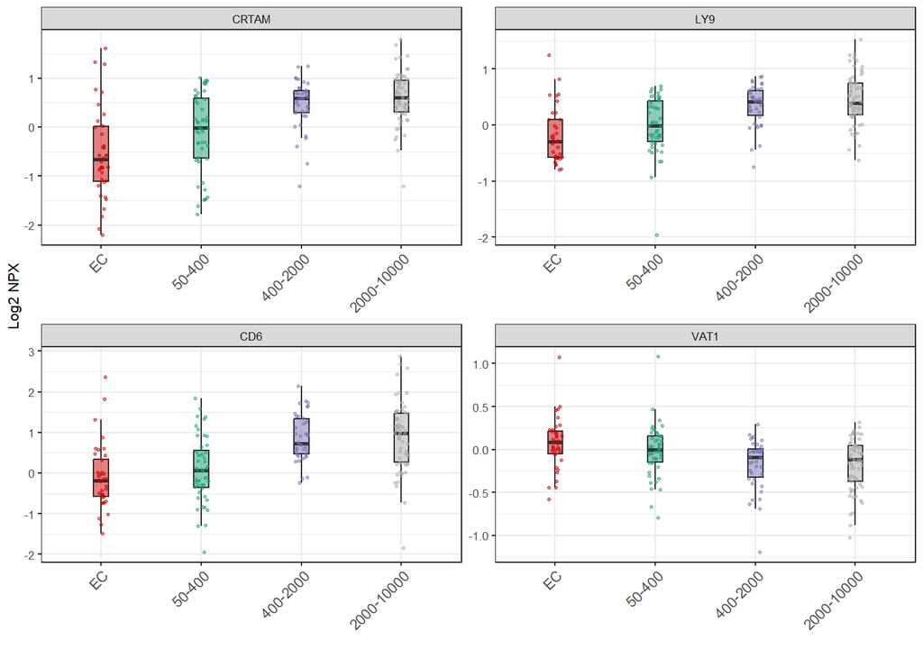

```r
melt_data %>%
  ggplot(aes(x = VL_cat, y = value, fill = VL_cat))+
  #geom_violin(alpha=0.3, position = position_dodge(width = .9), size=.1, color=NA) +
  geom_boxplot(notch = FALSE,  outlier.size = -1, width=.15,
               #color="black",
               lwd=.5, position = position_dodge(width = .9),
               alpha = 0.5,show.legend = F)+
  geom_jitter( shape= 21, size=.5,
               position = position_jitterdodge(dodge.width = .9),
               aes(color = VL_cat),alpha=.5)+
  ylab(c("Log2 NPX"))  +
  xlab(c("")) +
  facet_wrap(~Protein, scales = "free",ncol = 2)+#
  theme_bw(base_size = 8)+
  guides(fill = guide_legend(override.aes = list(alpha = .5,color="black")))+
  scale_fill_manual(values=c("red3","#1B9E77","#7570B3","darkgrey"))+ # green and purple from dark2 RColorBrewer::brewer.pal(8, "Dark2")
  scale_color_manual(values=c("red3","#1B9E77","#7570B3","darkgrey"))+
  theme(legend.position = "none",
        axis.text.x = element_text(size = 8, angle = 45, hjust = 1))
```

```r
ggsave(paste0(working_dir, "Outputs/Figure1E_Boxplot_147ARTnaiveVC_vs_36EC_2421Prots_AGE_SEX_CENTER_STORAGE_STRATIFIED_VL.pdf"), dpi = 300,width = 10, height = 10, units = "cm" )
```

#### 0.4.6.4 Supplementary boxplots, stratification by potential additional confounders

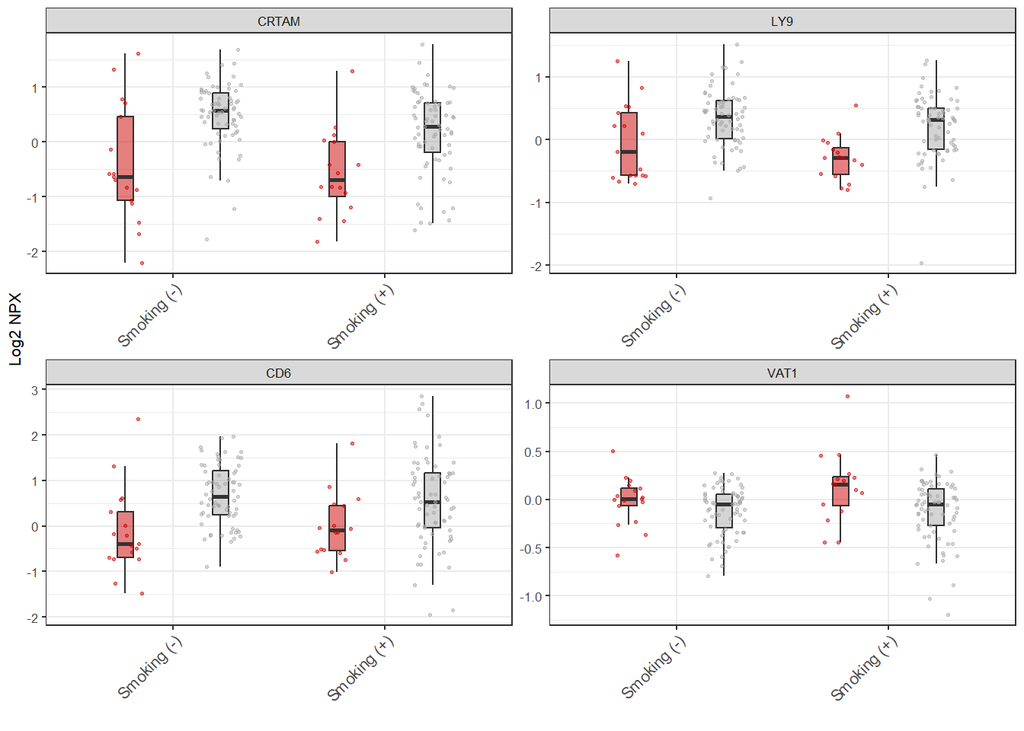

```r
### Figure S2A - SMOKING stratification
melt_data$SMOKING_CURRENT <- as.factor(melt_data$SMOKING_CURRENT)

melt_data %>%
  #filter(!is.na(T1_BMI))%>%
  filter(!is.na(SMOKING_CURRENT))%>%
  ggplot(aes(x = SMOKING_CURRENT, y = value, fill = NONVIREMIC))+
  #geom_violin(alpha=0.3, position = position_dodge(width = .9), size=.1, color=NA) +
  geom_boxplot(notch = FALSE,  outlier.size = -1, width=.15,
               #color="black",
               lwd=.5, position = position_dodge(width = .9),
               alpha = 0.5,show.legend = F)+
  geom_jitter( shape= 21, size=.5,
               position = position_jitterdodge(dodge.width = .9),
               aes(color = NONVIREMIC),alpha=.5)+
  ylab(c("Log2 NPX"))  +
  xlab(c(""))  +
  facet_wrap(~Protein, scales = "free",ncol = 2)+#
  theme_bw(base_size = 8)+
  guides(fill = guide_legend(override.aes = list(alpha = .5,color="black")))+
  scale_fill_manual(values=c("red3","darkgrey"))+
  scale_color_manual(values=c( "red3","darkgrey"))+
  theme(legend.position = "none",
        axis.text.x = element_text(size = 8, angle = 45, hjust = 1))
```

```r
ggsave(paste0(working_dir, "Outputs/Supplements_FigureS2A_Boxplot_Stratified_SMOKINGCURRENT.pdf"), dpi = 300,width = 10, height = 10, units = "cm" )

# print P values
for(protein in levels(melt_data$Protein)) {
  for(stratum in levels(melt_data$SMOKING_CURRENT)) {
  pval <- wilcox.test(melt_data[which(melt_data$Protein == protein &
                                melt_data$SMOKING_CURRENT == stratum),"value"] ~ # by EC/VC status
              melt_data[which(melt_data$Protein == protein &
                                melt_data$SMOKING_CURRENT == stratum),"NONVIREMIC"])$p.value
  print(paste(protein, stratum, pval))
}}
```

```
## [1] "CRTAM Smoking (-) 0.00119632072634968"
## [1] "CRTAM Smoking (+) 0.000930063265565409"
## [1] "LY9 Smoking (-) 0.00888890184785176"
## [1] "LY9 Smoking (+) 8.92956155869465e-05"
## [1] "CD6 Smoking (-) 0.000228627986312098"
## [1] "CD6 Smoking (+) 0.0154045795924884"
## [1] "VAT1 Smoking (-) 0.157387131516695"
## [1] "VAT1 Smoking (+) 0.00987629854756371"
```

```r
# Before, the P values were switched between smoking+ and smoking-
# double check the loop above with CRTAM and Smoking (-)
wilcox.test(melt_data[which(melt_data$Protein == "CRTAM" &
                                melt_data$SMOKING_CURRENT == "Smoking (-)"),"value"] ~ # by EC/VC status
              melt_data[which(melt_data$Protein == "CRTAM" &
                                melt_data$SMOKING_CURRENT == "Smoking (-)"),"NONVIREMIC"])
```

```
##
##  Wilcoxon rank sum test with continuity correction
##
## data:  melt_data[which(melt_data$Protein == "CRTAM" & melt_data$SMOKING_CURRENT == "Smoking (-)"), "value"] by melt_data[which(melt_data$Protein == "CRTAM" & melt_data$SMOKING_CURRENT == "Smoking (-)"), "NONVIREMIC"]
## W = 278, p-value = 0.001196
## alternative hypothesis: true location shift is not equal to 0
```

```r
# double check the loop above with CRTAM and Smoking (+)
wilcox.test(melt_data[which(melt_data$Protein == "CRTAM" &
                                melt_data$SMOKING_CURRENT == "Smoking (+)"),"value"] ~ # by EC/VC status
              melt_data[which(melt_data$Protein == "CRTAM" &
                                melt_data$SMOKING_CURRENT == "Smoking (+)"),"NONVIREMIC"])
```

```
##
##  Wilcoxon rank sum test with continuity correction
##
## data:  melt_data[which(melt_data$Protein == "CRTAM" & melt_data$SMOKING_CURRENT == "Smoking (+)"), "value"] by melt_data[which(melt_data$Protein == "CRTAM" & melt_data$SMOKING_CURRENT == "Smoking (+)"), "NONVIREMIC"]
## W = 257, p-value = 0.0009301
## alternative hypothesis: true location shift is not equal to 0
```

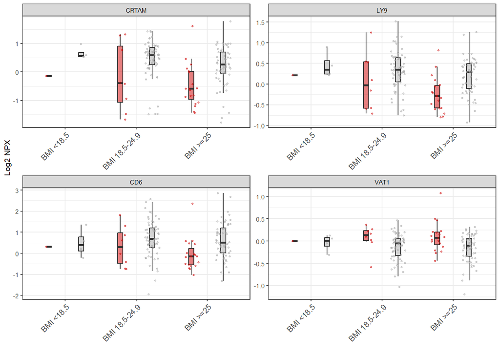

```r
### Figure S2B - BMI stratification
melt_data$BMI_cat2 <- factor(melt_data$BMI_cat2, levels = unique(melt_data$BMI_cat2)[c(4,1,2)])

melt_data %>%
  filter(!is.na(BMI_cat2))%>%
  ggplot(aes(x = BMI_cat2, y = value, fill = NONVIREMIC))+
  #geom_violin(alpha=0.3, position = position_dodge(width = .9), size=.1, color=NA) +
  geom_boxplot(notch = FALSE,  outlier.size = -1, width=.15,
               #color="black",
               lwd=.5, position = position_dodge(width = .9),
               alpha = 0.5,show.legend = F)+
  geom_jitter( shape= 21, size=.5,
               position = position_jitterdodge(dodge.width = .9),
               aes(color = NONVIREMIC),alpha=.5)+
  ylab(c("Log2 NPX"))  +
  xlab(c(""))  +
  facet_wrap(~Protein, scales = "free",ncol = 2)+#
  theme_bw(base_size = 8)+
  guides(fill = guide_legend(override.aes = list(alpha = .5,color="black")))+
  scale_fill_manual(values=c("red3","darkgrey"))+
  scale_color_manual(values=c( "red3","darkgrey"))+
  theme(legend.position = "none",
        axis.text.x = element_text(size = 8, angle = 45, hjust = 1))
```

```r
ggsave(paste0(working_dir, "Outputs/Supplements_FigureS2B_Boxplot_Stratified_BMIcategory.pdf"), dpi = 300,width = 10, height = 10, units = "cm" )

# P values
for(protein in levels(melt_data$Protein)) {
  for(stratum in levels(melt_data$BMI_cat2)) {
  pval <- wilcox.test(melt_data[which(melt_data$Protein == protein &
                                melt_data$BMI_cat2 == stratum),"value"] ~ # by EC/VC status
              melt_data[which(melt_data$Protein == protein &
                                melt_data$BMI_cat2 == stratum),"NONVIREMIC"])$p.value
  print(paste(protein, stratum, pval))
}}
```

```
## [1] "CRTAM BMI <18.5 0.4"
## [1] "CRTAM BMI 18.5-24.9 0.206285565054143"
## [1] "CRTAM BMI >=25 0.000401987117950724"
## [1] "LY9 BMI <18.5 0.4"
## [1] "LY9 BMI 18.5-24.9 0.193523580198341"
## [1] "LY9 BMI >=25 0.000230753143074119"
## [1] "CD6 BMI <18.5 1"
## [1] "CD6 BMI 18.5-24.9 0.295733098004824"
## [1] "CD6 BMI >=25 0.00115050271040291"
## [1] "VAT1 BMI <18.5 1"
## [1] "VAT1 BMI 18.5-24.9 0.0341300362849703"
## [1] "VAT1 BMI >=25 0.0156412661071581"
```

```r
### Figure S2C - ETHNICITY stratification
# add ethnicity_white
melt_data <- left_join(melt_data, master_df[c("ID","ETHNICITY_WHITE")], by = "ID")
melt_data$ETHNICITY_WHITE <- factor(melt_data$ETHNICITY_WHITE, levels = c(1,0), labels = c("White ethnicity", "Other ethnicity"))
summary(melt_data$ETHNICITY_WHITE)
```

```
## White ethnicity Other ethnicity            NA's
##             372             268              92
```

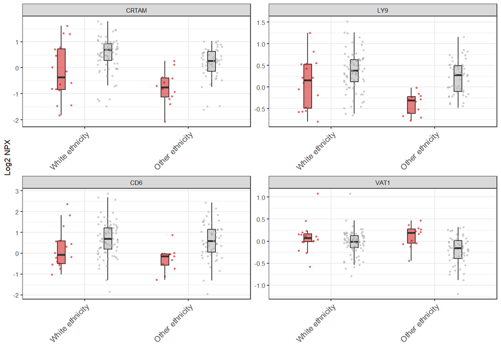

```r
melt_data %>%
  filter(!is.na(ETHNICITY_WHITE))%>%
  ggplot(aes(x = ETHNICITY_WHITE, y = value, fill = NONVIREMIC))+
  #geom_violin(alpha=0.3, position = position_dodge(width = .9), size=.1, color=NA) +
  geom_boxplot(notch = FALSE,  outlier.size = -1, width=.15,
               #color="black",
               lwd=.5, position = position_dodge(width = .9),
               alpha = 0.5,show.legend = F)+
  geom_jitter( shape= 21, size=.5,
               position = position_jitterdodge(dodge.width = .9),
               aes(color = NONVIREMIC),alpha=.5)+
  ylab(c("Log2 NPX"))  +
  xlab(c(""))  +
  facet_wrap(~Protein, scales = "free",ncol = 2)+#
  theme_bw(base_size = 8)+
  guides(fill = guide_legend(override.aes = list(alpha = .5,color="black")))+
  scale_fill_manual(values=c("red3","darkgrey"))+
  scale_color_manual(values=c( "red3","darkgrey"))+
  theme(legend.position = "none",
        axis.text.x = element_text(size = 8, angle = 45, hjust = 1))
```

```r
ggsave(paste0(working_dir, "Outputs/Supplements_FigureS2C_Boxplot_Stratified_ETHNICITYWHITE.pdf"), dpi = 300,width = 10, height = 10, units = "cm" )

# P values
for(protein in levels(melt_data$Protein)) {
  for(stratum in levels(melt_data$ETHNICITY_WHITE)) {
  pval <- wilcox.test(melt_data[which(melt_data$Protein == protein &
                                melt_data$ETHNICITY_WHITE == stratum),"value"] ~ # by EC/VC status
              melt_data[which(melt_data$Protein == protein &
                                melt_data$ETHNICITY_WHITE == stratum),"NONVIREMIC"])$p.value
  print(paste(protein, stratum, pval))
}}
```

```
## [1] "CRTAM White ethnicity 0.0200191688918611"
## [1] "CRTAM Other ethnicity 7.330399724574e-05"
## [1] "LY9 White ethnicity 0.0707851254926082"
## [1] "LY9 Other ethnicity 9.01682324772426e-06"
## [1] "CD6 White ethnicity 0.0229004408644778"
## [1] "CD6 Other ethnicity 0.000613236895560239"
## [1] "VAT1 White ethnicity 0.167797244238312"
## [1] "VAT1 Other ethnicity 0.00155582934030434"
```

### 0.4.7 Figure S2D - PC plot by plasma viral load

Since we identify the need for correcting our data, it is more meaningful to plot the PC1 and PC2 of the residuals, since the point of the figure is to show whethere there are differences by plasma VL category.

```r
# extract residuals after correcting for AGE, SEX, CENTER and STORAGE_TIME with LIMMA
npx <- master_df[,grep("Cardiometabolic|Inflammation|Neurology|Oncology", colnames(master_df))]

# Generate the protein expression matrix
eset <- as.matrix(t(npx))  # Transpose data
dim(eset) # [1] 2420  183
```

```
## [1] 2420  183
```

```r
# Design matrix
design_cov <- model.matrix(~ NONVIREMIC + AGE + SEX + CENTER + STORAGE_TIME, data = master_df)
#Fitting model
fit1_cov <- lmFit(eset, design_cov) # limma assumes log-transformed data, which the NPX values already are
# Limma residuals matrix
ResidualsMatrix <- residuals(fit1_cov, eset)

# store residuals in new dataframe for S2D
npx_s2d <- data.frame(t(ResidualsMatrix))
sum(rownames(master_df) == rownames(npx_s2d))
```

```
## [1] 183
```

```r
prin_comp <- prcomp(npx_s2d, center = T,scale. = T) # In Nadira's script, it was  `scale. = False`, although in the PC regressions and in Vicky's example script, we set scale.unit in PCA() always to True. Here I also set `scale. = T`.
summary(prin_comp)$importance[2,c(1:5)]
```

```
##     PC1     PC2     PC3     PC4     PC5
## 0.23565 0.08755 0.03778 0.03153 0.02384
```

```r
# Create VL category again
master_df <- master_df %>%
  mutate(VL_cat = case_when(VL <50 ~ "<50",
                            VL >= 50 & VL < 400 ~ "50-400",
                            VL >= 400 & VL < 2000 ~ "400-2000",
                            VL > 2000 ~ "2000-10000"))
master_df$VL_cat <- factor(master_df$VL_cat, levels = c("<50","50-400","400-2000","2000-10000"))
summary(master_df$VL_cat)
```

```
##        <50     50-400   400-2000 2000-10000
##         51         32         39         61
```

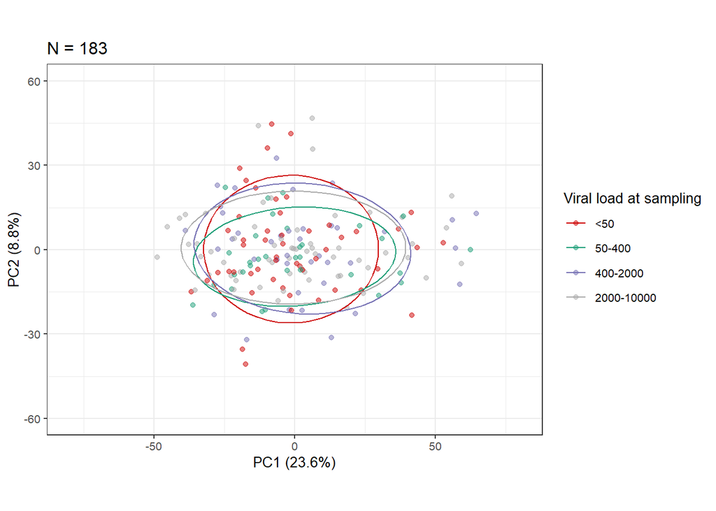

```r
# PCA Plot
 ggbiplot(prin_comp, obs.scale = 1, var.scale = 1,
              #labels = rownames(prin_comp$x),
              groups = as.factor(master_df$VL_cat),
              circle = F, ellipse = T, var.axes = F,
              alpha = 0.5,ellipse.fill = "none",ellipse.linewidth = 0.5)+
  #geom_point(shape=as.factor(df_m_1$NONVIREMIC),
  #           aes(colour=as.factor(master_df$VL_cat)),
  #           alpha = .5,
  #           size=1.5)+
  scale_color_manual(values = c("red3","#1B9E77","#7570B3","darkgrey"),name = "Viral load at sampling") +
  theme(legend.direction = 'horizontal',
        legend.position = 'top')+
  theme_bw(base_size=10)+
  labs(title ="N = 183") + ylim(-60,60) + xlim(-80,80)
```

```r
ggsave(paste0(working_dir, "Outputs/Supplements_FigureS2D_PCAresiduals_plot_vlcutoff_183samp_2420proteins.pdf"), dpi = 300, width = 11.25, height = 10, units = "cm" )
```

### 0.4.8 Figure S2E - corrplots with viral load

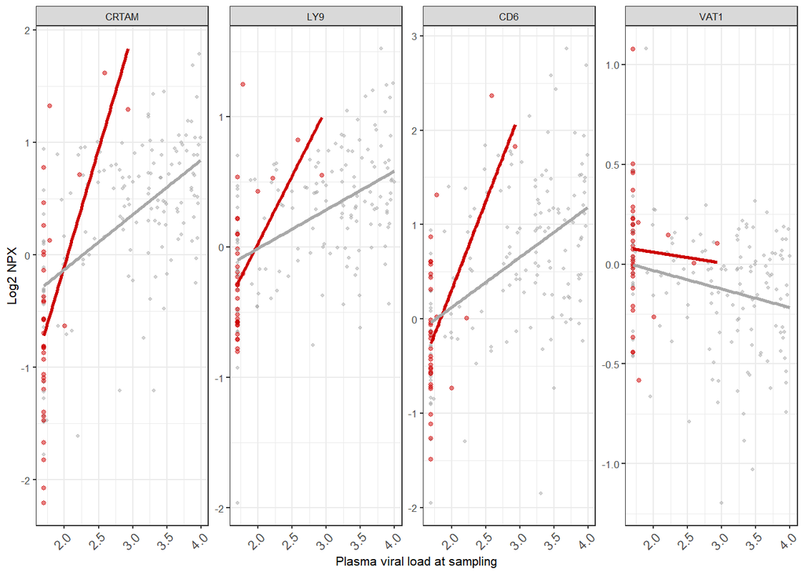

```r
melt_data$LOG10VL <- melt_data$VL
melt_data[which(melt_data$VL == 0),"LOG10VL"] <- 50
melt_data$LOG10VL <- log10(melt_data$LOG10VL)

melt_data %>%
  ggplot(aes(x = LOG10VL, y = value, color = NONVIREMIC)) +
  geom_point(alpha = 0.5, aes(size = NONVIREMIC)) +
  geom_smooth(method = "lm", se = FALSE) +
  xlab("Plasma viral load at sampling") +
  ylab("Log2 NPX") +
  facet_wrap(~Protein, scales = "free",ncol = 4)+
  theme_bw(base_size = 8)+
  guides(fill = guide_legend(override.aes = list(alpha = .5,color="black")))+
  scale_fill_manual(values=c("red3","darkgrey"))+
  scale_color_manual(values=c( "red3","darkgrey"))+
  scale_size_manual(values=c(1,0.75)) +
  theme(legend.position = "none",
        axis.text.x = element_text(size = 8, angle = 45, hjust = 1))
```

```r
ggsave(paste0(working_dir, "Outputs/Supplements_FigureS2E_Protein~VL_183samp_2420proteins.pdf"), dpi = 300, width = 19, height = 5, units = "cm" )
```

## 0.5 ART-naive EC and VC in 2000HIV (validation cohort)

Read data 2000HIV and prepare data.

```r
merge_df <- readRDS(paste0(working_dir, "Inputs/Validation2000HIVOlink_EC_vs_VC_Cleaned.rds")) %>% tidyr::drop_na(AGE, SEX_BIRTH, CENTER )
summary(merge_df$EC_combined)
```

```
## ARTnaive_VC          EC
##           5          14
```

```r
# ARTnaive_VC          EC
#           5          14

merge_df$EC_combined <- relevel(merge_df$EC_combined,"EC")
```

### 0.5.1 Compare ART-naive EC to ART-naive VC with wilcoxon/mannwhitney

We compare 5 VC vs 14 EC

```r
# calculate P values
wilcox.test(merge_df$CRTAM_Neurology~merge_df$EC_combined)#p-value = 0.007224
```

```
##
##  Wilcoxon rank sum exact test
##
## data:  merge_df$CRTAM_Neurology by merge_df$EC_combined
## W = 7, p-value = 0.007224
## alternative hypothesis: true location shift is not equal to 0
```

```r
summary(lm(merge_df$CRTAM_Neurology~merge_df$EC_combined+merge_df$AGE+merge_df$SEX_BIRTH))#p-value = 0.005552
```

```
##
## Call:
## lm(formula = merge_df$CRTAM_Neurology ~ merge_df$EC_combined +
##     merge_df$AGE + merge_df$SEX_BIRTH)
##
## Residuals:
##     Min      1Q  Median      3Q     Max
## -0.6891 -0.3077 -0.1329  0.2062  0.9680
##
## Coefficients:
##                                 Estimate Std. Error t value Pr(>|t|)
## (Intercept)                     1.322094   0.478318   2.764  0.01447 *
## merge_df$EC_combinedARTnaive_VC 0.834558   0.257979   3.235  0.00555 **
## merge_df$AGE                    0.007613   0.008677   0.877  0.39414
## merge_df$SEX_BIRTH1             0.015976   0.241196   0.066  0.94806
## ---
## Signif. codes:  0 '***' 0.001 '**' 0.01 '*' 0.05 '.' 0.1 ' ' 1
##
## Residual standard error: 0.4947 on 15 degrees of freedom
## Multiple R-squared:  0.4256, Adjusted R-squared:  0.3107
## F-statistic: 3.704 on 3 and 15 DF,  p-value: 0.03555
```

```r
wilcox.test(merge_df$LY9_Inflammation~merge_df$EC_combined)#p-value = 0.05573
```

```
##
##  Wilcoxon rank sum exact test
##
## data:  merge_df$LY9_Inflammation by merge_df$EC_combined
## W = 14, p-value = 0.05573
## alternative hypothesis: true location shift is not equal to 0
```

```r
summary(lm(merge_df$LY9_Inflammation~merge_df$EC_combined+merge_df$AGE+merge_df$SEX_BIRTH))#p-value = 0.0435
```

```
##
## Call:
## lm(formula = merge_df$LY9_Inflammation ~ merge_df$EC_combined +
##     merge_df$AGE + merge_df$SEX_BIRTH)
##
## Residuals:
##      Min       1Q   Median       3Q      Max
## -1.26555 -0.21553  0.02047  0.25448  0.86180
##
## Coefficients:
##                                  Estimate Std. Error t value Pr(>|t|)
## (Intercept)                     -0.193753   0.499026  -0.388   0.7033
## merge_df$EC_combinedARTnaive_VC  0.593326   0.269148   2.204   0.0435 *
## merge_df$AGE                     0.010223   0.009053   1.129   0.2765
## merge_df$SEX_BIRTH1              0.535424   0.251638   2.128   0.0504 .
## ---
## Signif. codes:  0 '***' 0.001 '**' 0.01 '*' 0.05 '.' 0.1 ' ' 1
##
## Residual standard error: 0.5161 on 15 degrees of freedom
## Multiple R-squared:  0.4021, Adjusted R-squared:  0.2825
## F-statistic: 3.363 on 3 and 15 DF,  p-value: 0.04697
```

```r
wilcox.test(merge_df$CD6_Inflammation~merge_df$EC_combined)#0.01032
```

```
##
##  Wilcoxon rank sum exact test
##
## data:  merge_df$CD6_Inflammation by merge_df$EC_combined
## W = 8, p-value = 0.01032
## alternative hypothesis: true location shift is not equal to 0
```

```r
summary(lm(merge_df$CD6_Inflammation~merge_df$EC_combined+merge_df$AGE+merge_df$SEX_BIRTH))#p-value = 0.00589
```

```
##
## Call:
## lm(formula = merge_df$CD6_Inflammation ~ merge_df$EC_combined +
##     merge_df$AGE + merge_df$SEX_BIRTH)
##
## Residuals:
##      Min       1Q   Median       3Q      Max
## -0.50899 -0.34025  0.05081  0.33340  0.60248
##
## Coefficients:
##                                  Estimate Std. Error t value Pr(>|t|)
## (Intercept)                      0.577514   0.384685   1.501  0.15404
## merge_df$EC_combinedARTnaive_VC  0.665140   0.207479   3.206  0.00589 **
## merge_df$AGE                    -0.002907   0.006978  -0.417  0.68287
## merge_df$SEX_BIRTH1              0.183248   0.193981   0.945  0.35980
## ---
## Signif. codes:  0 '***' 0.001 '**' 0.01 '*' 0.05 '.' 0.1 ' ' 1
##
## Residual standard error: 0.3978 on 15 degrees of freedom
## Multiple R-squared:  0.4429, Adjusted R-squared:  0.3315
## F-statistic: 3.975 on 3 and 15 DF,  p-value: 0.02869
```

```r
wilcox.test(merge_df$VAT1_Oncology~merge_df$EC_combined)#0.04369
```

```
##
##  Wilcoxon rank sum exact test
##
## data:  merge_df$VAT1_Oncology by merge_df$EC_combined
## W = 57, p-value = 0.04369
## alternative hypothesis: true location shift is not equal to 0
```

```r
summary(lm(merge_df$VAT1_Oncology~merge_df$EC_combined+merge_df$AGE+merge_df$SEX_BIRTH))#p-value = 0.042
```

```
##
## Call:
## lm(formula = merge_df$VAT1_Oncology ~ merge_df$EC_combined +
##     merge_df$AGE + merge_df$SEX_BIRTH)
##
## Residuals:
##      Min       1Q   Median       3Q      Max
## -0.40322 -0.25079  0.04558  0.09328  0.64887
##
## Coefficients:
##                                  Estimate Std. Error t value Pr(>|t|)
## (Intercept)                      0.185773   0.299910   0.619    0.545
## merge_df$EC_combinedARTnaive_VC -0.359508   0.161756  -2.223    0.042 *
## merge_df$AGE                     0.004258   0.005440   0.783    0.446
## merge_df$SEX_BIRTH1              0.224469   0.151232   1.484    0.158
## ---
## Signif. codes:  0 '***' 0.001 '**' 0.01 '*' 0.05 '.' 0.1 ' ' 1
##
## Residual standard error: 0.3102 on 15 degrees of freedom
## Multiple R-squared:  0.3249, Adjusted R-squared:  0.1899
## F-statistic: 2.407 on 3 and 15 DF,  p-value: 0.1078
```

```r
### Prepare data for boxplots
cocktails_df <- merge_df %>%
  dplyr::select("EC_combined",
                 "CRTAM_Neurology","LY9_Inflammation","CD6_Inflammation","VAT1_Oncology") #choose cell populations of interest

# pivot longer with melt() from reshape2
melt_data <- melt(cocktails_df)
melt_data <- melt_data %>%
  mutate(Protein = stringr::str_split_i(variable,"_",1),
         Panel = stringr::str_split_i(variable,"_",2))
melt_data$Protein <- factor(melt_data$Protein, levels = c("CRTAM","LY9","CD6","VAT1"))

# double check whether the data has been correctly transformed
head(melt_data)
```

```
##   EC_combined        variable   value Protein     Panel
## 1 ARTnaive_VC CRTAM_Neurology 2.85120   CRTAM Neurology
## 2 ARTnaive_VC CRTAM_Neurology 2.77125   CRTAM Neurology
## 3          EC CRTAM_Neurology 1.50655   CRTAM Neurology
## 4          EC CRTAM_Neurology 1.50895   CRTAM Neurology
## 5 ARTnaive_VC CRTAM_Neurology 2.23695   CRTAM Neurology
## 6          EC CRTAM_Neurology 1.69055   CRTAM Neurology
```

```r
table(melt_data$EC_combined, melt_data$Protein)
```

```
##
##               CRTAM LY9 CD6 VAT1
##   EC             14  14  14   14
##   ARTnaive_VC     5   5   5    5
```

#### 0.5.1.1 Figure 1D Violin plots Validation EC vs VC

```r
# Figure 1D Violin plots Discovery EC vs VC
g<-  ggplot(melt_data, aes(x = EC_combined, y = value, fill = EC_combined))+
  geom_violin(alpha=0.3, position = position_dodge(width = .9), linewidth=.1, color=NA) +
  geom_boxplot(notch = FALSE,  outlier.size = -1, width=.15,
               #color="black",
               lwd=.5, position = position_dodge(width = .9),
               alpha = 0.5,show.legend = F)+
  geom_jitter( shape= 21, size=.5,
               position = position_dodge2(width = 0.75),
               aes(color = EC_combined),alpha=.5)+
  ylab(c("Log2 NPX"))  +
  xlab(c(""))  +
  facet_wrap(~Protein, scales = "free",ncol = 2)+#
  theme_bw(base_size = 8)+
  guides(fill = guide_legend(override.aes = list(alpha = .5,color="black")))+
  scale_fill_manual(values=c("red3", "darkgrey"))+
  scale_color_manual(values=c("red3", "darkgrey"))+
  theme(legend.position = "none",
    axis.text.x = element_blank(),
    axis.ticks.x = element_blank())

ggsave(paste0(working_dir, "Outputs/Figure1D_Boxplot_ECVC_VALIDATION_CRTAMLY9CD6VAT1.pdf"),g, dpi = 300,width = 7, height = 7, units = "cm" )

g2 <- g + theme(legend.position = "right")
ggsave(paste0(working_dir, "Outputs/Figure1D_Boxplot_ECVC_VALIDATION_CRTAMLY9CD6VAT1_legend.pdf"),ggpubr::as_ggplot(ggpubr::get_legend(g2)), dpi = 300,width = 7, height = 7, units = "cm" )
```